# Minería de datos: PRA1 - Selección y preparación de un juego de datos

### Conclusiones

Hemos evaluado la calidad del agrupamiento de un modelo KMeans utilizando un subconjunto de datos de los iniciales, previamente normalizados, y lo hemos hecho variando el número de clusters entre 2 y 8. El objetivo es poder determinar este número de clusters óptimo para este algoritmo, que a priori no sabemos cual tiene que ser. El resultado que obtenemos es que dependiendo de la métrica de calidad que utilizemos, obtenemos un resultado distinto. De entre las métricas que hemos usado en este caso, obtenemos:

- Mirando el error cuadrático de las muestras del cluster (SSW), no tenemos claro qué valor elegir. Este valor queremos que sea lo menor posible, pero buscamos un punto de inflexión en la curva número de clusters frente a SSE para escogerlo, ya que la curva va a ser siempre descendente. Este punto de inflexión no lo encontramos ya que prácticamente es una línea recta.
- Mirando el índice Calinski-Harabasz elegiríamos 3 clusters como el número óptimo, que es el que maximiza su valor.
- Mirando el coeficiente silhouette y su promedio, elegiríamos 6 como el número de clusters óptimo, ya que se obtienen unos clusters razonables y se maximiza su valor promedio. No onstante, este valor es bastante bajo (0.18) teniendo en cuenta su valor óptimo (1).

Nos damos cuenta por lo tanto que la elección de un número de clusters no es única y depende de qué métrica miremos. Este es uno de los problemas del algoritmo KMeans, ya que tenemos que fijar previamente el número de clusters y esta elección puede ser compleja. Además, a vista de los resultados obtenidos, parece que los clusters de los datos originales no tienen fronteras muy definidas, pues los valores de calidad obtenidos no son muy altos.

## **Ejercicio 2**: Aplicar de nuevo el modelo anterior, pero usando una métrica distinta.

Utilizaremos ahora el mismo algoritmo de **KMeans**, pero esta vez aplicando una métrica de distancia diferente a la euclídea. En este caso, la librería Scikit-Learn no nos ofrece esta alternativa para el modelo KMeans, sino que este siempre opera con distancia euclídea, por lo que utilizamos la librería pyclustering, que sí nos lo permite. Utilizaremos la distancia **Chi-Square**.

```python
from pyclustering.cluster.kmeans import kmeans
from pyclustering.utils.metric import distance_metric
from pyclustering.cluster.center_initializer import kmeans_plusplus_initializer, random_center_initializer
from pyclustering.utils.metric import distance_metric, type_metric

def k_means_cluster (X, n_clusters, distance):
    initial_centers = random_center_initializer(X, n_clusters, random_state = 39).initialize()
    k_means = kmeans(X, initial_centers, metric = distance)
    k_means.process()
    # print(f'Number of clusters used: {len(initial_centers)}')
    # print('Samples by cluster: ', [len(ar) for ar in k_means.get_clusters()])
    return k_means

n_cluster = 5
kmeans_chisquare = k_means_cluster(X_norm, n_cluster, distance_metric(type_metric.CHI_SQUARE))
```

### Medidas de calidad del modelo

Hay que tener en cuenta que ahora, al utilizar una métrica distinta a la euclídea para el cálculo de las distancias, ambas no son comparables en magnitud.

```python
print(f'El error cuadrático es: {kmeans_chisquare.get_total_wce()}')
```

```
El error cuadrático es: 114998.77035878511
```

Realizamos un barrido con el número de clusters utilizado la distancia Chi-Square.

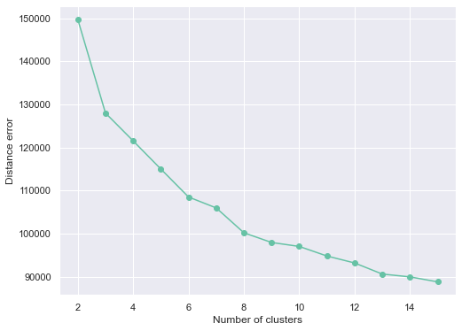

```python
distances_chisquare = []
ch_score_chisquare = []
for n_clusters in clusters_list:
    kmeans_chisquare = k_means_cluster(X_norm, n_clusters, distance_metric(type_metric.CHI_SQUARE))
    distances_chisquare.append(kmeans_chisquare.get_total_wce())
    cluster_labels = kmeans_chisquare.predict(X_norm)
    ch_score_chisquare.append(calinski_harabasz_score(X_norm, cluster_labels))
plt.figure(figsize=(8,6))
fig = plt.plot(clusters_list, distances_chisquare, marker='o')
plt.xlabel('Number of clusters')
plt.ylabel('Distance error')
plt.show()
```

La curva descendiente del error tiene una forma diferente a la que tenía en el caso de la distancia euclídea, y es más curvada. Aunque tampoco hay un valor claro de clusters que elegir como óptimo siguiendo el método *elbow*, en este caso sí podríamos elegir 6 u 8 como posibles candidatos, ya que a partir de este punto la mejora en distancia es mucho más lenta.

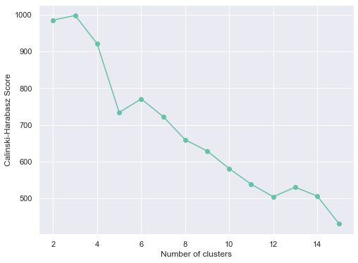

```python
plt.figure(figsize=(8,6))
fig = plt.plot(clusters_list, ch_score_chisquare, marker='o')
plt.xlabel('Number of clusters')
plt.ylabel('Calinski-Harabasz Score')
plt.show()
```

Bajo el criterio del índice Calinski-Harabasz, elegiríamos nuevamente como 3 el número óptimo de clusters, pues es el que maximiza su valor.

Realizamos el mismo análisis que hemos realizado con la distrancia euclídea en torno al coeficiente silhouette.

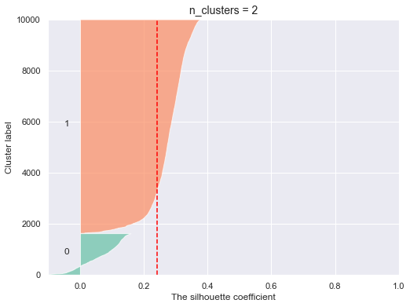

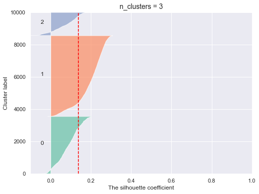

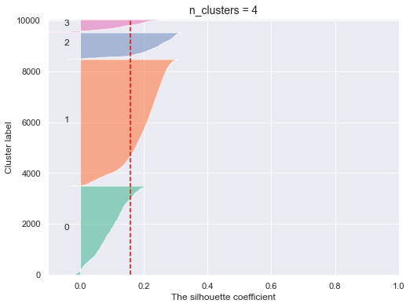

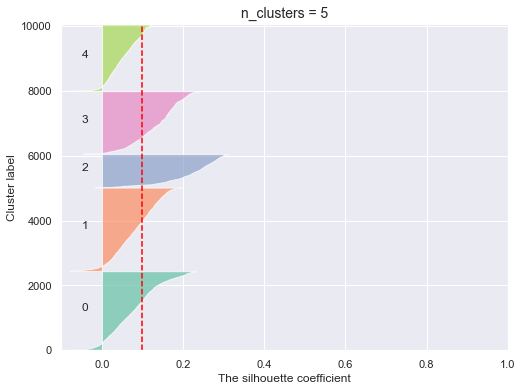

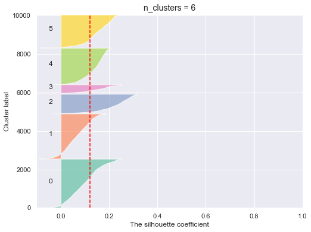

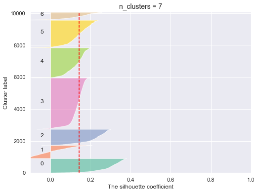

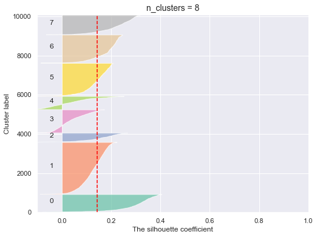

```python
range_n_clusters = np.arange(2, 9, 1)
sil_chisquare = []

for n_clusters in range_n_clusters:
    fig = plt.figure()
    fig.set_size_inches(8, 6)
    plt.title(f'n_clusters = {n_clusters}', fontsize=14)
    ax=plt.gca()
    ax.set_xlim([-0.1, 1])
    ax.set_ylim([0, X_norm.shape[0] + (n_clusters + 1) * 10])
    kmeans_chisquare = k_means_cluster(X_norm, n_clusters, distance_metric(type_metric.CHI_SQUARE))
    cluster_labels = kmeans_chisquare.predict(X_norm)
    silhouette_avg = silhouette_score(X_norm, cluster_labels)
    sil_chisquare.append(silhouette_avg)
    sample_silhouette_values = silhouette_samples(X_norm, cluster_labels)
    y_lower = 10

    for i in range(n_clusters):
        ith_cluster_silhouette_values = sample_silhouette_values[cluster_labels == i]
        ith_cluster_silhouette_values.sort()
        size_cluster_i = ith_cluster_silhouette_values.shape[0]
        y_upper = y_lower + size_cluster_i
        ax.fill_betweenx(np.arange(y_lower, y_upper), 0, ith_cluster_silhouette_values, alpha=0.7)
        ax.text(-0.05, y_lower + 0.5 * size_cluster_i, str(i))
        y_lower = y_upper + 10  # 10 for the 0 samples

    ax.set_xlabel('The silhouette coefficient')
    ax.set_ylabel('Cluster label')
    ax.axvline(x=silhouette_avg, color='red', linestyle='--')
    ax.set_xticks([0, 0.2, 0.4, 0.6, 0.8, 1])
    plt.show()
```

De las gráficas anteriores podemos sacar varias conclusiones:

- Con 2 clusters tenemos una media del coeficiente silhouette bastante alta, pero uno de los clusters tiene todas sus muestras muy por debajo de la media, lo cual nos indica un cluster muy disperso y por lo tanto de muy mala calidad.
- Las opciones de 3 y 4 clusters parecen las más adecuadas, a pesar de que en ambas hay algún cluster con la mayoría de las muestras por debajo de la media (línea roja).
- A partir de 5 clusters tenemos clusters con formas que se alejan mucho de la ideal de punta de cuchillo además de otros problemas, por lo que las descartaríamos.

Analizamos a continuación la media del coeficiente silhouette frente al número de clusters utilizado.

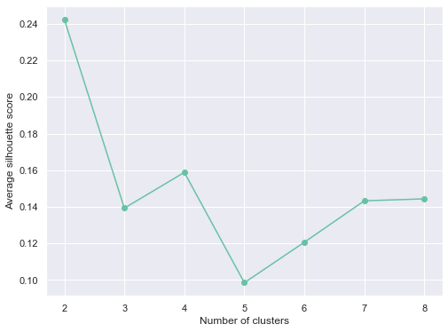

```python
plt.figure(figsize=(8,6))
plt.plot(range_n_clusters, sil_chisquare, marker='o')
plt.xlabel('Number of clusters')
plt.ylabel('Average silhouette score')
plt.show()
```

En base al análisis anterior y a que el número 4 maximiza el promedio del coeficiente silhouette (descartando el 2 por tener uno de los clusters muy malo), elegiríamos este número de k=4, obteniendo un valor promedio de 0.16.

### Comparación de los dos modelos no supervisados

Comparamos las dos versiones de algoritmos que hemos probado utilizando la métrica de promedio del coeficiente silhouette. Para ello, vamos a realizar la comparativa de los resultados obtenidos para cada valor de *k* (número de clusters), ya que dependiendo del valor seleccionado podemos encontrarnos con que sea mejor una u otra métrica de distancia.

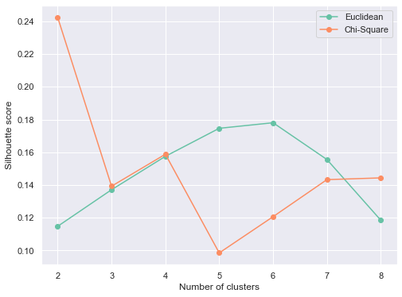

```python
plt.figure(figsize=(8,6))
plt.plot(range_n_clusters, sil_euclidean, marker='o', label='Euclidean')
plt.plot(range_n_clusters, sil_chisquare, marker='o', label='Chi-Square')
plt.xlabel('Number of clusters')
plt.ylabel('Silhouette score')
plt.legend()
plt.show()
```

Podemos ver en primer lugar como el coeficiente silhouette tiene un comportamiento mucho más consistente con la distancia euclídea, ya que su valor aumenta de forma suave hasta k=6 y luego empieza a descancer también de forma suave. Por contra, con la distancia Chi-Square este comportamiento es mucho más errático.

Descartando como hemos hecho antes el valor de k=2 para la distancia chi-sqare, ya que daba como resultado uno de los clusters muy malo, vemos como el mejor valor lo tenemos con la distancia euclídea y k=6. Curiosamente, para los valores k=3 y k=4 los resultados obtenidos con las dos distancias son muy similares.

Realizamos ahora la comparativa con la métrica Calinski-Harabasz.

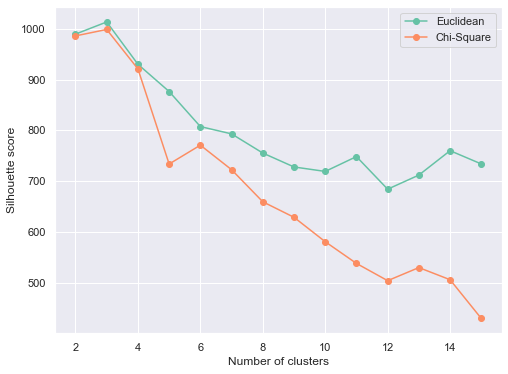

```python
plt.figure(figsize=(8,6))
plt.plot(clusters_list, ch_score_euclidean, marker='o', label='Euclidean')
plt.plot(clusters_list, ch_score_chisquare, marker='o', label='Chi-Square')
plt.xlabel('Number of clusters')
plt.ylabel('Silhouette score')
plt.legend()
plt.show()
```

### Conclusiones

Hemos podido comprobar cómo, dependiendo de la distancia que utilicemos en el algoritmo KMeans, así como de la métrica que utilicemos para valorar la calidad de la agrupación, elegiremos un valor u otro del parámetro k, que define el número de clusters que utilizaremos para la agrupación.

## **Ejercico 3**: Aplicar los algoritmos DBSCAN y OPTICS.

### Aplicación de DBSCAN

Aplicamos en primer lugar el algoritmo DBSCAN. Para ello, debemos especificar los parámetros *eps* y *min_samples*.

```python
from sklearn.cluster import DBSCAN

eps = 4
min_samples = 70
db = DBSCAN(eps=eps, min_samples=min_samples).fit(X_norm)
n_clusters_ = len(set(db.labels_)) - (1 if -1 in db.labels_ else 0)
n_noise_ = list(db.labels_).count(-1)

print(f'Number of clusters: {n_clusters_}')
print(f'Total number of points: {len(db.labels_)}')
print(f'Estimated number of noise points: {n_noise_}')
```

```
Number of clusters: 4
Total number of points: 10000
Estimated number of noise points: 1047
```

### Medida de calidad del agrupamiento

Obtenemos tres medidas de calidad del agrupamiento con el algoritmo DBSCAN que hemos realizado.

```python
from sklearn.metrics import davies_bouldin_score
print(f'Calinski and Harabasz score is: {calinski_harabasz_score(X_norm, db.labels_)}')
print(f'Davies Bouldin score is: {davies_bouldin_score(X_norm, db.labels_)}')
print(f'Mean silhouette score is: {silhouette_score(X_norm, db.labels_)}')
```

```
Calinski and Harabasz score is: 425.4882854514484
Davies Bouldin score is: 2.89752924802987
Mean silhouette score is: 0.13635800753485244
```

### Se prueba con diferentes valores de eps

El algoritmo DBSCAN tiene dos parámetros fundamentales que lo definen:

- *eps*: determina la distancia máxima entre dos muestras para que éstas sean consideradas vecinas.
- *min_samples*: determina el número mínimo de puntos vecinos que tiene que tiene que tener un punto para ser considerado punto núcleo.

Como podemos variar ambos parámetros para conseguir una combinación óptima de éstos, lo haremos, en lugar de modificar sólo el valor de *eps*.

```python
silhouette_dbscan  = {}
ch_score_dbscan = {}
num_clusters_dbscan = {}
num_noise_pt_dbscan = {}
eps_vals = np.arange(2, 8.5, 0.5)
min_samples_vals = np.arange(40, 81, 5)
for eps_val in eps_vals:
    silhouette_dbscan[eps_val] = {}
    ch_score_dbscan[eps_val] = {}
    num_clusters_dbscan[eps_val] = {}
    num_noise_pt_dbscan[eps_val] = {}
    for min_samples in min_samples_vals:
        db = DBSCAN(eps=eps_val, min_samples=min_samples, n_jobs=16).fit(X_norm)
        labels = db.labels_
        n_clusters_ = len(set(db.labels_)) - (1 if -1 in db.labels_ else 0)
        n_noise_ = list(db.labels_).count(-1)
        # print(f'With eps = {eps_val} and min_samples = {min_samples} we have {n_clusters_} clusters and {n_noise_} noise points.')
        ch_score_dbscan[eps_val][min_samples] = calinski_harabasz_score(X_norm, db.labels_)
        silhouette_dbscan[eps_val][min_samples] = silhouette_score(X_norm, db.labels_)
        num_clusters_dbscan[eps_val][min_samples] = n_clusters_
        num_noise_pt_dbscan[eps_val][min_samples] = n_noise_
```

```python
silhouette_df = pd.DataFrame(silhouette_dbscan)
ch_scores_df = pd.DataFrame(ch_score_dbscan)
num_clusters_df = pd.DataFrame(num_clusters_dbscan)
```

Como tenemos dos parámetros como variables independientes, dibujamos en un mapa de calor con los valores de ambas variables en ambos ejes y el valor de la métrica mapeado en el color. Además, sobre el elemento indicamos el número de clusters que hemos obtenido con esa configuración en concreto. Esto es importante porque, pese a tener un mejor valor en una métrica, puede darse que el número de clusters sea uno, caso que deberíamos descartar porque no tiene sentido, o éste sea muy grande y lo descartemos por este hecho.

En primer lugar representamos el valor del coeficiente silhouette medio, realizado como la media del coeficiente silhouette para cada una de las muestras del set de datos.

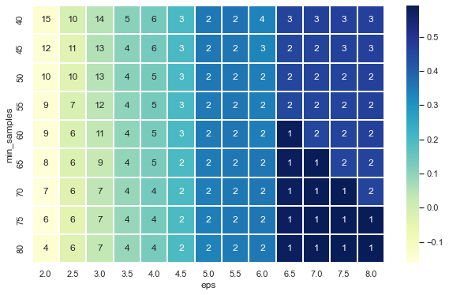

```python
fig = plt.figure(figsize =(10,6))
ax = sns.heatmap(silhouette_df, annot=num_clusters_df, linewidths=1, cmap="YlGnBu")
plt.xlabel('eps')
plt.ylabel('min_samples')
plt.show()
```

Analizando los datos del mapa, podemos ver como el mayor valor de silhouette se da en los casos en los que tenemos un sólo cluster. Como ese caso no lo tomaremos como válido, elegiríamos cualquiera de las combinaciones de zona superior derecha, que tienen el mismo valor de la métrica, la segunda más alta, y la división es en dos clusters. Un ejemplo sería eps = 7 y min_samples = 60.

También podemos comprobar que, como nos dice la teoría, y como regla general, el número de clusters va a ser menor cuando aumentamos los valores de los parámetros *eps* y *min_samples*.

```python
print(f'Percentage of points not assign to a cluster (noise points): {num_noise_pt_dbscan[7.0][60]/X_norm.shape[0]*100:.2f}')
```

```
Percentage of points not assign to a cluster (noise points): 1.62
```

Vemos que con la elección realizada además tenemos un número de puntos no asignados a ningun cluster muy bajo.

A continuación realizamos la misma representación para el caso de la métrica Calinski & Harabasz.

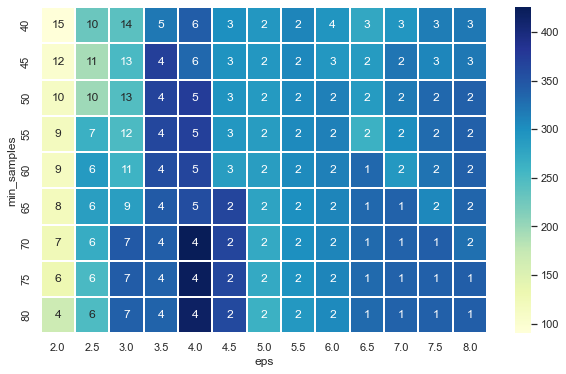

```python
fig = plt.figure(figsize =(10,6))
ax = sns.heatmap(ch_scores_df, annot=num_clusters_df, linewidths=1, cmap="YlGnBu")
plt.xlabel('eps')
plt.ylabel('min_samples')
plt.show()
```

Evidentemente en este caso tenemos el mismo número de clusters en cada una de las conbinaciones de parámetros *eps* y *min_samples* porque al algoritmo aplicado es el mismo, pero tenemos mapeado en el color la métrica Calinski & Harabasz. Teniendo en cuenta esta métrica nos quedaríamos con el valor de eps = 4 y min_samples = 70, ya que es la combinación que nos proporciona un valor más alto, y el número de clusters resultante sería de 4, a diferencia que los dos que teníamos en el caso anterior.

```python
print(f'Percentage of points not assign to a cluster (noise points): {num_noise_pt_dbscan[4.0][70]/X_norm.shape[0]*100:.2f}')
```

```
Percentage of points not assign to a cluster (noise points): 10.47
```

Con esta elección de parámetros tendríamos un porcentaje de puntos no asignado a nungún cluster más alto que con la elección anterior, pero todavía un número razonablemente bajo.

Realizamos un análisis del coeficiente silhouette fijando *min_samples* a 60 (valor medio de los probados anteriormente) y haciendo un barrido de valores de *eps*.

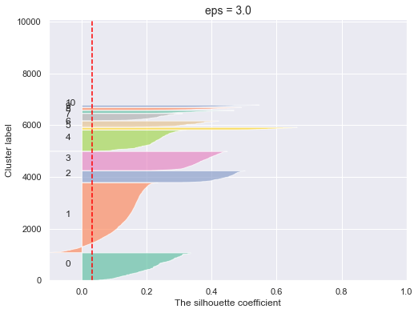

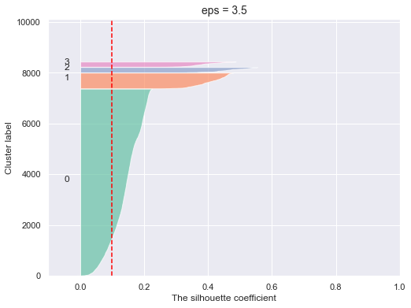

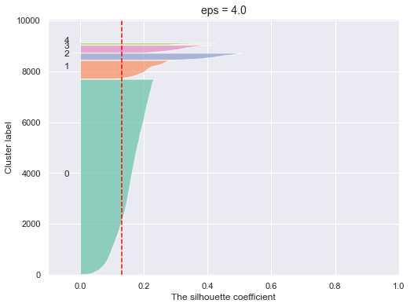

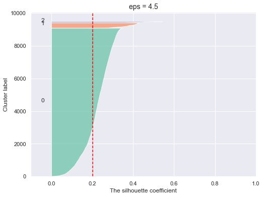

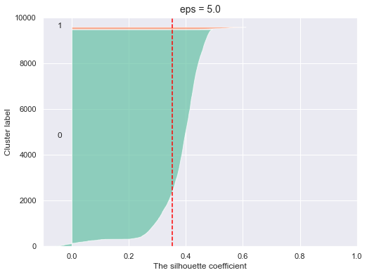

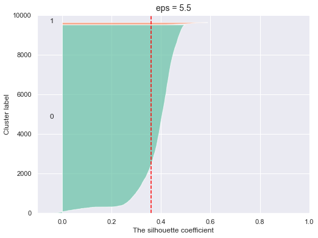

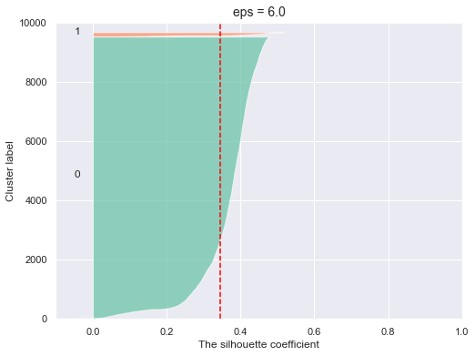

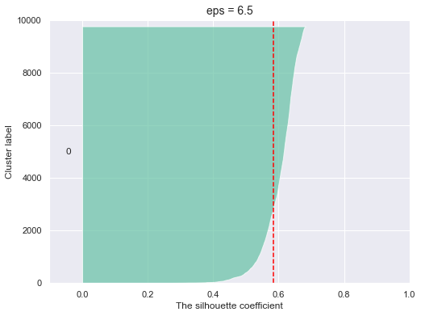

```python
eps_range = np.arange(3, 7, 0.5)
min_samples = 60

sil_db = []

for eps in eps_range:
    fig = plt.figure()
    fig.set_size_inches(8, 6)
    plt.title(f'eps = {eps}', fontsize=14)
    ax=plt.gca()
    ax.set_xlim([-0.1, 1])
    ax.set_ylim([0, X_norm.shape[0] + (n_clusters + 1) * 10])
    db = DBSCAN(eps=eps, min_samples=min_samples).fit(X_norm)
    silhouette_avg = silhouette_score(X_norm, db.labels_)
    sil_db.append(silhouette_avg)
    sample_silhouette_values = silhouette_samples(X_norm, db.labels_)
    y_lower = 10
    n_clusters = len(set(db.labels_)) - (1 if -1 in db.labels_ else 0)

    for i in range(n_clusters):
        ith_cluster_silhouette_values = sample_silhouette_values[db.labels_ == i]
        ith_cluster_silhouette_values.sort()
        size_cluster_i = ith_cluster_silhouette_values.shape[0]
        y_upper = y_lower + size_cluster_i
        ax.fill_betweenx(np.arange(y_lower, y_upper), 0, ith_cluster_silhouette_values, alpha=0.7)
        ax.text(-0.05, y_lower + 0.5 * size_cluster_i, str(i))
        y_lower = y_upper + 10  # 10 for the 0 samples

    ax.set_xlabel('The silhouette coefficient')
    ax.set_ylabel('Cluster label')
    ax.axvline(x=silhouette_avg, color='red', linestyle='--')
    ax.set_xticks([0, 0.2, 0.4, 0.6, 0.8, 1])
    plt.show()
```

Del análisis del las gráficas anteriores podemos extraer las siguientes conclusiones:

- Con eps=3 tenemos una gran cantidad de elementos clarificados como *outliers*, así como muchos clusters muy pequeños.
- Con eps=3.5 el número de clusters se reduce a 4. Sin embargo, tres de ellos son muy pequeños y el cuarto ocupa la gran mayoría de muestras, caso que no es ideal. Además, seguimos teniendo demasiados puntos clasificados como *outliers*
- Con eps=4 el número de clusters aumenta a 5 y tenemos los mismos problemas que en el caso anterior.
- A partir de eps=4.5, tenemos muy pocas muestras catalogadas como *outliers* pero básicamente nos quedamos con un sólo cluster que agrupa todas o casi todas las muestras, ya que el resto de clusters, si existe, son muy pequeños, y eso raramente es deseable. En estos casos el valor del coeficiente silhouette medio aumenta mucho, pero es debido a que casi todos los puntos pertenecen a un único cluster.

### OPTICS

El algoritmo OPTICS es muy exigente computacionalmente y no es paralelizable para correr en diferentes núcleos de la CPU, por lo que el entrenamiento se hace muy lento con el subconjunto que ya habíamos tomado de 10000 muestras, por lo que lo reducimos mucho más hasta las 1000 unidades.

```python
np.random.seed(41)
X_norm_sub = X_norm[np.random.choice(X_norm.shape[0], 1000, replace=False)]
X_norm_sub.shape
```

```
(1000, 33)
```

Ahora vamos a aplicar el algoritmo OPTICS. El algoritmo OPTICS funciona de forma muy similar al DBSCAN, pero en este caso no tenemos que fijar el valor de *eps* de antemano. Sí que podremos fijar un número máximo de *eps*, que fijaremos a un número relativamente alto para que no sea limitante, pero por otro lado que nos recorte el tiempo de procesado, que en caso contrario es muy alto. El parámetro importante a definir en este caso es el *min_samples*, que tiene la misma interpretación que en DBSCAN.

```python
from sklearn.cluster import OPTICS

optics_clust = OPTICS(min_samples=20, max_eps=20).fit(X_norm_sub)
n_clusters_ = len(set(optics_clust.labels_)) - (1 if -1 in optics_clust.labels_ else 0)
print(f'Number of clusters: {n_clusters_}')
```

```
Number of clusters: 5
```

Calculamos el coeficiente silhouette medio para la agrupación que se ha realizado.

```python
silhouette_score(X_norm_sub, optics_clust.labels_)
```

```
-0.08104450131361865
```

Vemos como el valor obtenido en esta métrica es especialmente malo, ya que está por debajo de 0. Eso quiere defir que en media la mayoría de puntos han sido asignados a un cluster distinto al que debería.

```python
print(f'Number of noise points not assign to a cluster: {sum(optics_clust.labels_==-1)/X_norm_sub.shape[0]*100:.2f}')
```

```
Number of noise points not assign to a cluster: 78.50
```

Encontramos la causa del problema y es que, efectivamente, la gran mayoría de puntos no han sido asignados a ninguno de los 5 clusteres que se han formado, sino han sido marcados como *outliers*. Evidentemente, este no es un resultado razonable y debemos descartarlo.

EL algoritmo OPTICS en realidad asigna a cada muestra una reachability distance, que será la mayor valor entre la core distance y la distancia euclídea entre la muestra y su core. Dibujamos esta reachability distance ordenando los puntos y asignando un color a cada clase, donde los puntos negros son outliers.

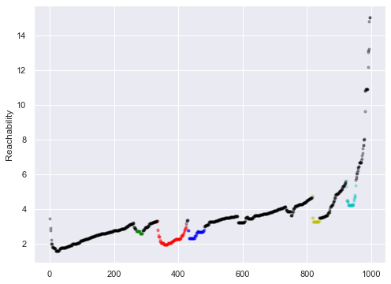

```python
reachability = optics_clust.reachability_[optics_clust.ordering_]
labels = optics_clust.labels_[optics_clust.ordering_]
space = np.arange(len(labels))
colors = ["g", "r", "b", "y", "c", 'm']
plt.figure(figsize=(8,6))
for cl, color in zip(range(0, n_clusters_), colors[:n_clusters_]):
    Xk = space[labels == cl]
    Rk = reachability[labels == cl]
    plt.plot(Xk, Rk, color=color, alpha=0.3, linestyle='', marker='o', markersize=3)
plt.plot(space[labels == -1], reachability[labels == -1], "k.", alpha=0.3)
plt.ylabel("Reachability")
plt.show()
```

Vemos como en el reachability plot existen zonas valle que definen cada uno de los clusters con su color correspondiente, en este caso 5. Además, cuanto más profundo el valle querrá decir que mayor es la densidad de puntos de ese cluster.

Podemos comprobar como efectivamente el número de puntos no asignados a ningún cluster (en negro) es muy alto, por lo que no parece que el resultado obtenido con este algoritmo sea en ningún caso aceptable. Se ha probado con distintos valores de *min_samples* e incluso utilizando una métrica distinta para el cálculo de la distancia, pero como vamos a ver en ningún caso se han logrado resultados aceptables con este algoritmo, tomando como aceptable aquel que devuelva un número razonable de clusters y en el que el número de puntos no asignados a ningún cluster sea relativamente bajo.

```python
from sklearn.cluster import OPTICS

n_clust = []
sil_scores = []
ch_scores = []
noise_pt = []

min_samples_vals = np.arange(5, 25, 1)

for min_samples in min_samples_vals:
    optics_clust = OPTICS(min_samples=min_samples, max_eps=35).fit(X_norm_sub)
    n_clusters_ = len(set(optics_clust.labels_)) - (1 if -1 in optics_clust.labels_ else 0)
    n_clust.append(n_clusters_)
    sil_scores.append(silhouette_score(X_norm_sub, optics_clust.labels_))
    ch_scores.append(calinski_harabasz_score(X_norm_sub, optics_clust.labels_))
    noise_pt.append(sum(optics_clust.labels_==-1))
```

Revisamos los resultados del paramétrico en forma de tabla.

```python
report_optics_df = pd.DataFrame({'min_samples': min_samples_vals,
                                 'clusters': n_clust,
                                 'noise_pt': noise_pt,
                                 'silhouette_score': sil_scores,
                                 'ch_score': ch_scores
                                })
report_optics_df
```

|  | min_samples | clusters | noise_pt | silhouette_score | ch_score |
| --- | --- | --- | --- | --- | --- |
| 0 | 5 | 32 | 753 | -0.229940 | 6.445072 |
| 1 | 6 | 20 | 813 | -0.252232 | 6.816852 |
| 2 | 7 | 18 | 769 | -0.232874 | 10.088932 |
| 3 | 8 | 12 | 754 | -0.177717 | 15.581466 |
| 4 | 9 | 11 | 800 | -0.202740 | 15.183053 |
| 5 | 10 | 7 | 840 | -0.133780 | 14.489013 |
| 6 | 11 | 6 | 860 | -0.126218 | 15.634491 |
| 7 | 12 | 5 | 887 | -0.155081 | 14.774889 |
| 8 | 13 | 5 | 819 | -0.075168 | 21.925464 |
| 9 | 14 | 5 | 821 | -0.078529 | 21.668040 |
| 10 | 15 | 5 | 808 | -0.081942 | 21.992924 |
| 11 | 16 | 3 | 861 | -0.060951 | 27.647388 |
| 12 | 17 | 3 | 857 | -0.056114 | 28.274381 |
| 13 | 18 | 4 | 829 | -0.060390 | 27.432602 |
| 14 | 19 | 3 | 855 | -0.056081 | 28.329907 |
| 15 | 20 | 5 | 785 | -0.081045 | 24.521571 |
| 16 | 21 | 3 | 897 | -0.050655 | 23.991448 |
| 17 | 22 | 3 | 895 | -0.056004 | 21.865953 |
| 18 | 23 | 2 | 947 | -0.012649 | 22.105984 |
| 19 | 24 | 1 | 972 | 0.169086 | 29.885124 |

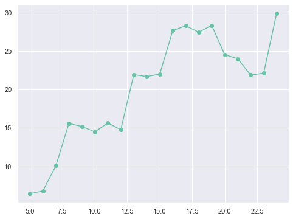

```python
plt.figure(figsize=(8,6))
plt.plot(min_samples_vals, ch_scores, marker='o')
plt.show()
```

### Comparativa y conclusiones

Estos resultados son debidos a que el dataset que tenemos no tiene unos clusters más o menos bien definidos, sino que que son una nube de puntos en el espacio n-dimensional sin divisiones claras, por lo que DBSCAN y OPTICS, que buscan las mayores densidades de puntos, no funcionan correctamente. Kmeans, sin embargo, siempre funciona y divide los puntos atendiendo a la distancia entre ellos, pero de los valores que obtenemos en el coeficiente silhouette medio, por ejemplo, podemos observar que su agrupación en clusters no es muy buena, ya que éstos no están claros.

También hemos podido comprobar cómo el algoritmo kmeans es bastante más rápido, y juntando ésto con los resultados anteriores es el que deberíamos elegir en nuestro caso si quisiésemos realizar un clustering con los tipos de reservas de hoteles.

Evidentemente, estas conclusiones las obtenemos con este dataset elegido, y no sería así con otro que sí tuviese unas fronteras entre clusters más definidas. En un caso más general, las ventajas e inconvenientes de kmeans y DBSCAN son las siguientes:

Las ventajas de kmeans son las siguientes:

- Es mucho más rápido, lo que permite utilizarlo cuando el número de puntos es grande.
- Sólo requiere definir un parámetro.
- No se ve afectado por variaciones en la densidad de los clusters.

Los inconvenientes de kmeans son los siguientes:

- Los clusters tienen una forma aproximadamente esférica, por lo que no es válido si los clusters no tienen dicha forma.
- Tienes que definir de antemano el número de clusters a utilizar.
- Es muy sensible a la presencia de outliers en los datos.

Las ventajas de DBSCAN son las siguientes:

- Detecta clusters de forma arbitraria, a diferencia de k-means.
- No necesita que se le especifique el número de clusters a priori, algo que k-means sí necesita.
- Es menos sensible a ruido y robusto frente a la presencia de valores outliers.
- Permite la detección directa de valores outliers dentro de los datos.

Los inconvenientes de DBSCAN son:

- La elección de los parámetros eps y min_samples puede ser compleja, como hemos comprobado en el ejercicio.
- No consigue realizar un buen agrupamiento cuando hay clusters con densidades de puntos muy distintas.

## **Ejercico 4**: Aplicar un modelo de generación de reglas a partir de árboles de decisión.

### Generación del modelo

A la hora de aplicar algoritmos supervisados, trataremos sólamente con el conjunto de entrenamiento y no tocaremos el conjunto de test ni tomaremos ninguna decisión en base a él hasta que queramos hacer la última validación de la calidad del modelo. Por otro lado, en los modelos de árbol de decisión no es necesario realizar una normalización de los datos de entrada al modelo, por lo que no lo haremos.

El criterio que utilizaremos para la división de las ramas del árbol es la optimización de la la ganancia en información o minimización de la entropía. Por otro lado, tenemos varios parámetros que podemos configurar a la hora de crear un árbol de decisión en sklearn para poder restringirlo y lidiar con el overfitting que tienden a sufrir este tipo de modelos:

- *max_depth*: Especifica la profundidad máxima que puede tener el árbol.
- *min_samples_leaf*: Especifica el número mínimo de muestras que debe tener cada hoja del árbol.
- *max_leaf_nodes*: Especifica el número máximo de hojas que se pueden crear.

En un primer modelo, elegimos estos parámetros de forma razonable para que no salga un árbol excesivamente grande, ya que disponemos de muchas variables de entrada, y si no restringimos el árbol, su tamaño puede ser muy grande.

```python
from sklearn.tree import DecisionTreeClassifier

dt_classifier = DecisionTreeClassifier(criterion = 'entropy',
                                       max_depth=7,
                                       min_samples_leaf=100,
                                       max_leaf_nodes = 50,
                                       random_state=41)

dt_classifier.fit(X_train, y_train)
```

```
DecisionTreeClassifier(criterion='entropy', max_depth=7, max_leaf_nodes=50,
                       min_samples_leaf=100, random_state=41)
```

Las variables de entrada que tenemos en el modelo son las siguientes.

```python
print(dt_classifier.feature_names_in_.tolist())
```

[output not shown]

### Extracción de reglas

Del árbol de decisión entrenado en el paso anterior podemos extraer las reglas y mostrarlas en forma de texto.

```python
from sklearn.tree import export_text

text_tree = export_text(dt_classifier, feature_names=dt_classifier.feature_names_in_.tolist())
print(text_tree)
```

```
|--- is_international <= 0.50
|   |--- lead_time <= 24.50
|   |   |--- required_car_parking_spaces <= 0.50
|   |   |   |--- lead_time <= 7.50
|   |   |   |   |--- previous_bookings_not_canceled <= 0.50
|   |   |   |   |   |--- stays_in_weekend_nights <= 1.50
|   |   |   |   |   |   |--- adr <= 77.55
|   |   |   |   |   |   |   |--- class: False
|   |   |   |   |   |   |--- adr >  77.55
|   |   |   |   |   |   |   |--- class: False
|   |   |   |   |   |--- stays_in_weekend_nights >  1.50
|   |   |   |   |   |   |--- market_segment_Offline TA/TO <= 0.50
|   |   |   |   |   |   |   |--- class: False
|   |   |   |   |   |   |--- market_segment_Offline TA/TO >  0.50
|   |   |   |   |   |   |   |--- class: True
|   |   |   |   |--- previous_bookings_not_canceled >  0.50
|   |   |   |   |   |--- class: False
|   |   |   |--- lead_time >  7.50
|   |   |   |   |--- previous_cancellations <= 0.50
|   |   |   |   |   |--- room_changed <= 0.50
|   |   |   |   |   |   |--- previous_bookings_not_canceled <= 0.50
|   |   |   |   |   |   |   |--- class: False
|   |   |   |   |   |   |--- previous_bookings_not_canceled >  0.50
|   |   |   |   |   |   |   |--- class: False
|   |   |   |   |   |--- room_changed >  0.50
|   |   |   |   |   |   |--- class: False
|   |   |   |   |--- previous_cancellations >  0.50
|   |   |   |   |   |--- distribution_channel_TA/TO <= 0.50
|   |   |   |   |   |   |--- class: True
|   |   |   |   |   |--- distribution_channel_TA/TO >  0.50
|   |   |   |   |   |   |--- class: True
|   |   |--- required_car_parking_spaces >  0.50
|   |   |   |--- class: False
|   |--- lead_time >  24.50
|   |   |--- total_of_special_requests <= 0.50
|   |   |   |--- room_changed <= 0.50
|   |   |   |   |--- customer_type_Transient-Party <= 0.50
|   |   |   |   |   |--- market_segment_Groups <= 0.50
|   |   |   |   |   |   |--- required_car_parking_spaces <= 0.50
|   |   |   |   |   |   |   |--- class: True
```

[output cut: 93 more lines]

```
|   |   |   |   |--- customer_type_Transient <= 0.50
|   |   |   |   |   |--- customer_type_Transient-Party <= 0.50
|   |   |   |   |   |   |--- class: False
|   |   |   |   |   |--- customer_type_Transient-Party >  0.50
|   |   |   |   |   |   |--- class: False
|   |   |   |   |--- customer_type_Transient >  0.50
|   |   |   |   |   |--- lead_time <= 8.50
|   |   |   |   |   |   |--- class: False
|   |   |   |   |   |--- lead_time >  8.50
|   |   |   |   |   |   |--- room_changed <= 0.50
|   |   |   |   |   |   |   |--- class: False
|   |   |   |   |   |   |--- room_changed >  0.50
|   |   |   |   |   |   |   |--- class: False
|   |   |   |--- required_car_parking_spaces >  0.50
|   |   |   |   |--- class: False
```

Observando el árbol, se pueden comentar varias cosas de forma rápida:

- La primera división del árbol se lleva a cabo con la variable *is_international*. No sorprende este resultado, pues en la PRA1 ya habíamos visto que el porcentaje de cancelación era muy diferentes entre reservas nacionales e internacionales. De hecho, esta variable no existía en el dataset original la generamos a partir del país de procedencia de los clientes, y ha demostrado ser una variable predictora excepcionalmente interesante.
- En los siguientes niveles de división del árbol se tienen en cuenta las variables *lead_time* y *market_segment_Online TA*. Esta segunda variable es la que indica si *market_segment* es "Online TA" en formato *one hot encoding*.

Representamos ahora el árbol de decisión obtenido en forma gráfica.

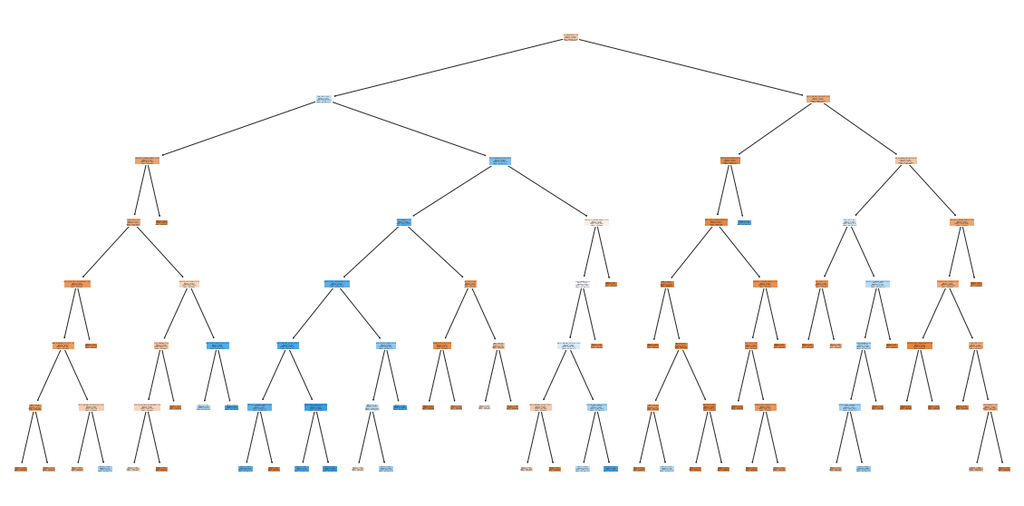

```python
from sklearn.tree import plot_tree, export_graphviz

plt.figure(figsize=(20, 10))
plot_tree(dt_classifier, feature_names=dt_classifier.feature_names_in_.tolist(), class_names=['Canceled', 'Not canceled'], filled=True)
plt.show()
```

Como a pesar de haber limitado el tamaño del árbol este sigue siendo muy grande, vamos a crear un segundo modelo aumentando las restricciones todavía más (limitando el número de hojas y la profundidad máxima) para poder visualizarlo correctamente de forma gráfica y poder interpretarlo mejor.

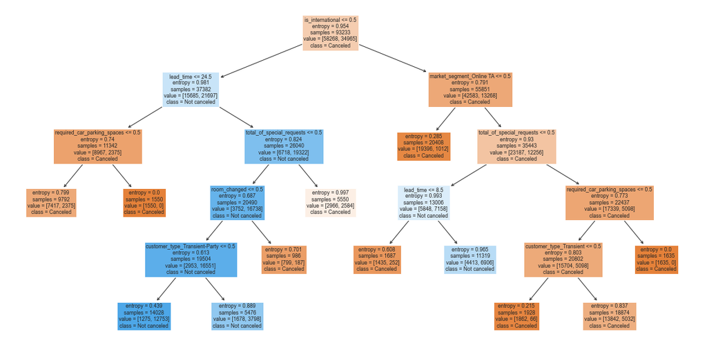

```python
dt_classifier2 = DecisionTreeClassifier(criterion = 'entropy',
                                        max_depth=5,
                                        min_samples_leaf=0.01,
                                        max_leaf_nodes = 12,
                                        random_state=41)

dt_classifier2.fit(X_train, y_train)

plt.figure(figsize=(20, 10))
plot_tree(dt_classifier2, feature_names=dt_classifier2.feature_names_in_.tolist(), class_names=['Canceled', 'Not canceled'], filled=True)
plt.show()
```

Volviendo al primer modelo que hemos generado, obtenemos las variables que más importancia tienen en la clasificación, tomando éstas como las que mayor ganancia en información aportan en la división en las ramas del árbol.

```python
df_feat_impor = pd.DataFrame({'Feature': dt_classifier.feature_names_in_, 'Importance': dt_classifier.feature_importances_})
df_feat_impor.sort_values('Importance', axis=0, ascending=False, inplace=True)
df_feat_impor
```

|  | Feature | Importance |
| --- | --- | --- |
| 0 | lead_time | 0.229680 |
| 14 | is_international | 0.204900 |
| 25 | market_segment_Online TA | 0.141562 |
| 11 | total_of_special_requests | 0.114897 |
| 10 | required_car_parking_spaces | 0.076200 |
| 15 | room_changed | 0.066048 |
| 7 | previous_cancellations | 0.047079 |
| 23 | market_segment_Groups | 0.028062 |
| 32 | customer_type_Transient-Party | 0.024317 |
| 31 | customer_type_Transient | 0.023183 |
| 9 | adr | 0.016730 |
| 26 | distribution_channel_Direct | 0.011608 |
| 8 | previous_bookings_not_canceled | 0.004934 |
| 28 | distribution_channel_TA/TO | 0.003881 |
| 3 | adults | 0.003011 |
| 1 | stays_in_weekend_nights | 0.002099 |
| 24 | market_segment_Offline TA/TO | 0.000944 |
| 12 | arrival_month_sin | 0.000864 |
| 30 | customer_type_Group | 0.000000 |
| 29 | distribution_channel_Undefined | 0.000000 |
| 27 | distribution_channel_GDS | 0.000000 |
| 2 | stays_in_week_nights | 0.000000 |
| 21 | market_segment_Corporate | 0.000000 |
| 22 | market_segment_Direct | 0.000000 |
| 20 | market_segment_Complementary | 0.000000 |
| 19 | meal_SC | 0.000000 |
| 18 | meal_HB | 0.000000 |
| 17 | meal_FB | 0.000000 |
| 4 | children | 0.000000 |
| 5 | babies | 0.000000 |
| 13 | arrival_month_cos | 0.000000 |
| 6 | is_repeated_guest | 0.000000 |
| 16 | hotel_Resort Hotel | 0.000000 |

Representamos de forma visual las variables que se utilizan en el árbol de decisión y su importancia.

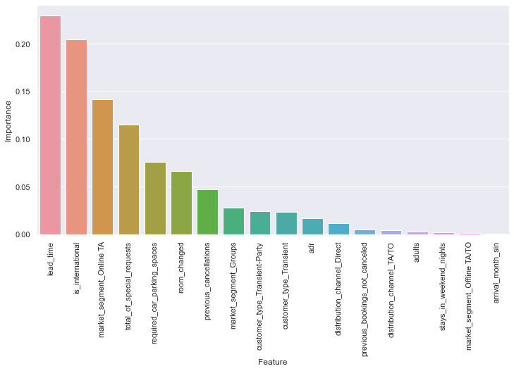

```python
plt.figure(figsize=(12,6))
sns.barplot(data=df_feat_impor[df_feat_impor['Importance']>0], x='Feature', y='Importance')
plt.xticks(rotation=90)
plt.show()
```

Podemos ver que variables como *lead_time*, que representa la antelación con la que se realiza la reserva, *is_international*, que representa si la reserva la realiza un extranjero, si el *market_segment* es "Online TA" o el número de peticiones especiales son las que más importancia tienen a la hora de determinar la clase predicha una vez está entrenado el modelo.

### Evaluación del modelo

Para evaluar el modelo no utilizaremos de momento el conjunto de test, ya que éste lo utilizaremos en el último momento. Utilizaramos el método de cross-validation con *k-folds*, que nos ofrece dos ventajas fundamentales:

- Evitamos evaluar el modelo con un conjunto específico de muestras, que haya que podamos tener incertidumbre sobre si el modelo generaliza bien sobre datos no vistos o si lo hace sobre esos datos en concreto reservados para test.
- Podemos realizar una evaluación de distintos modelos sin reservar muestras de evaluación aparte, quedándonos con menos muestras para el entrenamiento del modelo. Realizaremos el cross-validation con 10 *folds*. Esto nos obligará a entrenar 10 modelos en lugar de uno sólo.

```python
from sklearn.model_selection import cross_validate

score_types = ['accuracy', 'precision', 'recall', 'f1', 'roc_auc']

cv_scores = cross_validate(dt_classifier, X_train, y_train, cv=10, return_train_score=True, scoring=score_types, n_jobs=8)
```

```python
def show_mean_scores(scores):
    scores_dict = {'train':{}, 'test':{}}
    for k, v in scores.items():
        if 'train' in k:
            scores_dict['train'][k.split('_')[1]] = np.mean(v)
        elif 'test' in k:
            scores_dict['test'][k.split('_')[1]] = np.mean(v)
    return pd.DataFrame(scores_dict)

show_mean_scores(cv_scores)
```

|  | train | test |
| --- | --- | --- |
| accuracy | 0.827279 | 0.826960 |
| precision | 0.792257 | 0.791957 |
| recall | 0.731265 | 0.730587 |
| f1 | 0.760503 | 0.759973 |
| roc | 0.902304 | 0.901759 |

Si nos fijamos en los resultados de los conjuntos de test, podemos ver que no tenemos valores malos teniendo en cuenta que se trata de un primer modelo sin ajustar, y conseguimos una exactitud de más del 82%. También llama la atención el áerea bajo la curva ROC, que lo tenemos en un valor de 0.9 aproximadamente. Podemos observar además cómo tenemos unos resultados muy similares en todas las medidas de calidad en el conjunto de entrenamiento y en el de test, lo cual es un indicativo de que probablemente estemos en un caso de *underfitting* provocado por un modelo que es demasiado sencillo para ajustar correctamente nuestros datos. Esto quiere decir que probablemente conseguiríamos un resultado medio mejor en los conjuntos de evaluación si tuviésemos un árbol más complejo, con menos restricciones que las que hemos impuesto.

De la misma manera podemos obtener las predicciones con cross-validation y obtener la matriz de confusión.

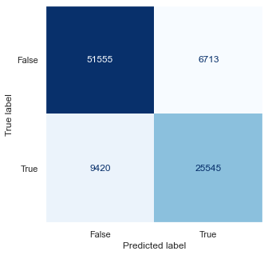

```python
from sklearn.model_selection import cross_val_predict
from sklearn.metrics import confusion_matrix, ConfusionMatrixDisplay

y_pred = cross_val_predict(dt_classifier, X_train, y_train, cv=10, n_jobs=8)
plt.figure(figsize=(10,5))
ConfusionMatrixDisplay.from_predictions(y_train, y_pred, colorbar=False, cmap='Blues', ax=plt.gca())
plt.grid(False)
plt.show()
```

De la matriz de confusión podemos decir que de las 34965 muestras de la clase "True" (reservas no canceladas), 25545 se han correctamente clasificado como "True", lo que hace un 73%, valor que correponde con el *recall* que hemos calculado en el punto anterior. Por otro lado, de las 32258 muestras que se han clasificado como "True", sólo lo eran 25545, que son un 79% y corresponde con el valor de *precision* que hemos calculado.

Suponiendo que el modelo que tenemos fuese el elegido entre los valorados, y quisiésemos evaluar el comportamiento final del modelo en muestras nunca vistas, podríamos utilizar para ello el conjunto de muestras de test que tenemos reservadas para ello.

```python
from sklearn.metrics import accuracy_score

y_test_pred = dt_classifier.predict(X_test)
print(f'Train accuracy score is : {np.mean(cv_scores["train_accuracy"])*100:.2f}%')
print(f'Evaluation accuracy score by cross-validation is : {np.mean(cv_scores["test_accuracy"])*100:.2f}%')
print(f'Final test accuracy score is : {accuracy_score(y_test, y_test_pred)*100:.2f}%')
```

```
Train accuracy score is : 82.73%
Evaluation accuracy score by cross-validation is : 82.70%
Final test accuracy score is : 82.51%
```

Nuevamente vemos que el conjunto de test tiene una exactitud prácticamnte idéntica a la que encontramos en los conjuntos de evaluación y de entrenamiento. Que los resultados de evaluación y test sean similares no es algo extraño, y es lo que debería suceder. Que el conjunto de entrenamiento se comporte igual ya hemos comentado que se debe a que probablemente nuestro modelo sufre de *underfitting*.

### Evaluación de modelo alternativo

Como hemos creado un álbol demasido sencillo cuyas reglas pudiésemos interpretar más fácilmente pero que sufre de *underfitting*, creamos, entrenamos y evaluamos un nuevo árbol sin ningún tipo de restricción, de modo que pueda ser todo lo complejo que determinen sus variables de entrada y posibles divisiones.

```python
decission_tree = DecisionTreeClassifier(criterion = 'entropy', random_state=41)

cv_scores3 = cross_validate(decission_tree, X_train, y_train, cv=10, return_train_score=True, scoring=score_types, n_jobs=8)
```

```python
show_mean_scores(cv_scores3)
```

|  | train | test |
| --- | --- | --- |
| accuracy | 0.995212 | 0.845774 |
| precision | 0.997031 | 0.791062 |
| recall | 0.990181 | 0.800200 |
| f1 | 0.993594 | 0.795573 |
| roc | 0.999941 | 0.838888 |

Comprobamos como con éste árbol obtenemos mejores valores en casi todas las medidas de calidad en el conjunto de test, que es el realmente relevante. Sin embargo, en en área bajo la curva ROC hemos perdido bastante. Además, vemos cómo ahora el conjunto de entrenamiento tiene un comportamiento prácticamente perfecto en cualquier métrica. Por ejemplo, la exactitud es del 99.5%, mientras que ésta en el conjunto de test es del 84.5%. Esta divergencia lleva a pensar que con éste modelo nos hayamos pasado de complejidad en el modelo y ahora suframos de *overfitting*, aprendiendo perfectamente las peculiaridades del conjunto de muestras de entrenamiento pero no generalizando tan bien sobre las muestras no vistas de test.

### Optimización o *parameter hypertuning*

Como con los dos modelos anteriores sufíamos de *underfitting* en el primero y de *overfitting* en el segundo, nos plantemos realizar una búsqueda de la mejor combinación de estos tres parámetros con los que estamos jugando que nos ofrezca una clasificación óptima. Realizamos esta búsqueda, estableciendo varias opciones para cada uno de los tres parámetros y realizando un proceso de *cross-validation* para cada posible combinación de ellos.

```python
from sklearn.model_selection import GridSearchCV

parameters = {'max_depth':[6,8,10,12,14],
              'min_samples_leaf':[1,10,100,1000,10000],
              'max_leaf_nodes':[20,50,100,200,400]}
decission_tree = DecisionTreeClassifier(criterion = 'entropy', random_state=41)
dt_clf_gs = GridSearchCV(decission_tree, parameters, scoring=score_types, cv=5, n_jobs=16, refit='accuracy')
dt_clf_gs.fit(X_train, y_train)
```

```
GridSearchCV(cv=5,
             estimator=DecisionTreeClassifier(criterion='entropy',
                                              random_state=41),
             n_jobs=16,
             param_grid={'max_depth': [6, 8, 10, 12, 14],
                         'max_leaf_nodes': [20, 50, 100, 200, 400],
                         'min_samples_leaf': [1, 10, 100, 1000, 10000]},
             refit='accuracy',
             scoring=['accuracy', 'precision', 'recall', 'f1', 'roc_auc'])
```

```python
gs_results = pd.DataFrame(dt_clf_gs.cv_results_)[['param_max_depth',
                                                  'param_max_leaf_nodes',
                                                  'param_min_samples_leaf',
                                                  'mean_test_accuracy',
                                                  'mean_test_recall',
                                                  'mean_test_precision',
                                                  'mean_test_f1',
                                                  'mean_test_roc_auc']]
gs_results.sort_values('mean_test_roc_auc', ascending=False).head(10)
```

|  | param_max_depth | param_max_leaf_nodes | param_min_samples_leaf | mean_test_accuracy | mean_test_recall | mean_test_precision | mean_test_f1 | mean_test_roc_auc |
| --- | --- | --- | --- | --- | --- | --- | --- | --- |
| 120 | 14 | 400 | 1 | 0.848251 | 0.762334 | 0.820390 | 0.790246 | 0.925337 |
| 121 | 14 | 400 | 10 | 0.846535 | 0.758959 | 0.818706 | 0.787646 | 0.925176 |
| 116 | 14 | 200 | 10 | 0.844218 | 0.752667 | 0.817494 | 0.783722 | 0.922474 |
| 115 | 14 | 200 | 1 | 0.844422 | 0.752352 | 0.818184 | 0.783869 | 0.922465 |
| 90 | 12 | 200 | 1 | 0.842513 | 0.750722 | 0.814818 | 0.781428 | 0.921044 |
| 96 | 12 | 400 | 10 | 0.842566 | 0.752095 | 0.814111 | 0.781786 | 0.920905 |
| 95 | 12 | 400 | 1 | 0.843757 | 0.754583 | 0.815166 | 0.783654 | 0.920879 |
| 91 | 12 | 200 | 10 | 0.842084 | 0.751895 | 0.813061 | 0.781216 | 0.920731 |
| 117 | 14 | 200 | 100 | 0.838845 | 0.740798 | 0.812956 | 0.775157 | 0.918706 |
| 122 | 14 | 400 | 100 | 0.839134 | 0.741198 | 0.813373 | 0.775560 | 0.918675 |

Vemos en la tabla cómo la mejor combinación dentro de las que hemos probado es la de *param_max_depth* = 14, *param_max_leaf_nodes* = 400 y *param_min_samples_leaf* = 1, que en este caso, y dentro de las combinaciones que hemos probado, es la restringe menos el tamaño del árbol, por lo que podemos decir que necesitamos un árbol grande o con pocas restricciones para optimizar el comportamiento del modelo. Esto seguramente sea debido a que tenemos un dataset con muchas muestras en relación al número de características que tenemos, por lo que la penalización del rendimiento del modelo en evaluación por *overfitting* es más difícil que se produzca. Con un dataset más reducido con menos muestras, seguramanete el problema de *overfitting* sería bastante más notable.

Evaluamos las métricas en los conjuntos de entrenamiento y evaluación con *cross-validation* del modelo que mejor resultado nos ha dado atendiendo a la métrica de *accuracy*.

```python
cv_scores4 = cross_validate(dt_clf_gs.best_estimator_, X_train, y_train, cv=10, return_train_score=True, scoring=score_types, n_jobs=8)
show_mean_scores(cv_scores4)
```

|  | train | test |
| --- | --- | --- |
| accuracy | 0.857761 | 0.847929 |
| precision | 0.831872 | 0.818130 |
| recall | 0.778105 | 0.764736 |
| f1 | 0.804031 | 0.790420 |
| roc | 0.935839 | 0.925477 |

Podemos comprobar de los datos como efectivamente ahora el modelo no está sufriendo de *overfitting* o al menos éste es muy débil, ya que el comportamiento en ambos conjuntos de datos es similar, y en el de entrenamiento es sólo ligeramente superior.

### Modelo con poda

Para podar el árbol de decisión, haremos uso del parámetro *ccp_alpha* que nos ofrece sklearn, que nos da esta posibilidad. Realizaremos la poda a partir del árbol sin ninguna restricción de tamaño ni de ninguna clase, con sus parámetros por defecto, y por lo tanto permitiendo el máximo nivel de *overfitting*.

```python
from sklearn.model_selection import GridSearchCV

parameters = {'ccp_alpha':list(np.arange(0,0.0003,0.00001))}

dt_pruning_gs = GridSearchCV(decission_tree, parameters, scoring=score_types, return_train_score=True, refit='accuracy', cv=5, n_jobs=16)
dt_pruning_gs.fit(X_train, y_train)
```

```
GridSearchCV(cv=5,
             estimator=DecisionTreeClassifier(criterion='entropy',
                                              random_state=41),
             n_jobs=16,
             param_grid={'ccp_alpha': [0.0, 1e-05, 2e-05,
                                       3.0000000000000004e-05, 4e-05, 5e-05,
                                       6.000000000000001e-05,
                                       7.000000000000001e-05, 8e-05, 9e-05,
                                       0.0001, 0.00011, 0.00012000000000000002,
                                       0.00013000000000000002,
                                       0.00014000000000000001,
                                       0.00015000000000000001, 0.00016, 0.00017,
                                       0.00018, 0.00019, 0.0002, 0.00021,
                                       0.00022, 0.00023, 0.00024000000000000003,
                                       0.00025, 0.00026000000000000003, 0.00027,
                                       0.00028000000000000003, 0.00029]},
             refit='accuracy', return_train_score=True,
             scoring=['accuracy', 'precision', 'recall', 'f1', 'roc_auc'])
```

Guardamos el modelo que mejor resultado nos ha dado en *accuracy*.

```python
best_pruned_dt = dt_pruning_gs.best_estimator_
best_pruned_dt
```

```
DecisionTreeClassifier(ccp_alpha=8e-05, criterion='entropy', random_state=41)
```

Vemos la tabla de resultados ordenando en forma descendente por la exactitud.

```python
results = pd.DataFrame(dt_pruning_gs.cv_results_)[['param_ccp_alpha',
                                                   'mean_train_accuracy',
                                                   'mean_test_accuracy',
                                                   'mean_test_recall',
                                                   'mean_test_precision',
                                                   'mean_test_f1',
                                                   'mean_test_roc_auc']]
results.sort_values('mean_test_accuracy', ascending=False).head(10)
```

|  | param_ccp_alpha | mean_train_accuracy | mean_test_accuracy | mean_test_recall | mean_test_precision | mean_test_f1 | mean_test_roc_auc |
| --- | --- | --- | --- | --- | --- | --- | --- |
| 8 | 0.00008 | 0.878045 | 0.855126 | 0.774317 | 0.828270 | 0.800351 | 0.925583 |
| 9 | 0.00009 | 0.872859 | 0.854730 | 0.773230 | 0.828056 | 0.799689 | 0.927741 |
| 10 | 0.0001 | 0.868904 | 0.854515 | 0.773145 | 0.827661 | 0.799429 | 0.928288 |
| 11 | 0.00011 | 0.866418 | 0.854150 | 0.773173 | 0.826754 | 0.799037 | 0.928309 |
| 12 | 0.00012 | 0.863916 | 0.853904 | 0.769484 | 0.828782 | 0.797997 | 0.928641 |
| 7 | 0.00007 | 0.885880 | 0.853893 | 0.768912 | 0.829118 | 0.797865 | 0.921441 |
| 13 | 0.00013 | 0.862323 | 0.853367 | 0.767997 | 0.828520 | 0.797094 | 0.928286 |
| 14 | 0.00014 | 0.860280 | 0.852617 | 0.766166 | 0.828007 | 0.795876 | 0.927903 |
| 15 | 0.00015 | 0.858422 | 0.852230 | 0.761075 | 0.830717 | 0.794361 | 0.927578 |
| 6 | 0.00006 | 0.899698 | 0.851705 | 0.776634 | 0.818691 | 0.797073 | 0.911560 |

```python
print(f'Mean test accuracy for best pruned tree is: {results["mean_test_accuracy"].max()*100:.2f}%')
```

```
Mean test accuracy for best pruned tree is: 85.51%
```

Vemos como no sólamente la exactitud ha mejorado, sino que también lo he hecho el área bajo la curva ROC, en la que tenemos en algunos casos valores cercanos al 0.93, una mejora considerable respecto al árbol inicial, en el que teníamos 0.9. También hemos mejorado los resultados iniciales si nos fijamos en las métricas *precision*, *recall* o *f1-score*.

Vemos la evolución del *accuracy* cuando modificamos el nivel de poda del árbol.

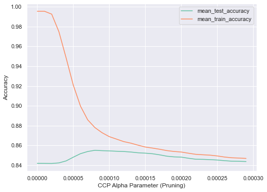

```python
plt.figure(figsize=(8,6))
results.set_index('param_ccp_alpha')[['mean_test_accuracy', 'mean_train_accuracy']].plot(kind='line', ax=plt.gca())
plt.xlabel('CCP Alpha Parameter (Pruning)')
plt.ylabel('Accuracy')
plt.show()
```

La interpretación de esta gráfica es la siguiente:

- La exactitud en el conjunto de entrenamiento es mejor cuando no se produce nada de poda, como es lógico. Un árbol sin podar con la máxima complejidad permite ajustarse a los datos de entrenamiento de la mejor forma y de esta manera obtener la máxima exactidud, siendo ésta casi perfecta (~1).
- Cuando el podado comienza, la exactitud en el conjunto de entrenamiento baja drásticamente, hasta un punto en el que se acerca mucho al del conjunto de evaluación y comienza a descender lentamente junto con éste si seguimos aumentando el nivel de poda.
- Cuando comienza el podado, sin embargo, la exactitud en el conjunto de evaluación comienza a mejorar hasta un máximo, a partir del cual comienza a descender lentamente.
- En la zona anterior a ese máximo, estamos en una zona de claro *overfitting*, donde la exactitud del conjunto de entrenamiento es muy superior a la de evaluación, ya que el modelo no generaliza bien. A partir de ese punto, y para valores más altos del parámetro, se produce el caso de un ligero *underfitting*, ya que el modelo no es lo suficientemente complejo, y por lo tanto el comportamiento en el conjunto de evaluación va empeorando de forma lenta.
- El punto óptimo del parámetro estaría donde el *accuracy* del conjunto de evaluación tiene su máximo, con un *ccp_alpha* de aproximadamente 0.00008.

Aunque vemos que con podado podemos mejorar los resultados, en este caso en concreto con este dataset, la mejora no es muy grande, ya que supera apenas el 1% en exactitud respecto a un árbol sin ningún tipo de poda.

### Modelo con boosting

Creamos un modelo de árbol de decisión con *adaptative boosting*, que crea varios árboles de decisión en secuencia, cada uno de ellos centrado en clasificar mejor las muestras que no se clasificaron correctamente en el anterior. Al final, la clasificación se realizará por votación de todos los árboles creados, asignándoles a cada uno de ellos un peso. Para realizar este modelo de *ensamble*, utilizamos AdaBoostClassifier de scikit-learn.

```python
from sklearn.ensemble import AdaBoostClassifier
from sklearn.model_selection import cross_val_score

boost_dt = AdaBoostClassifier(decission_tree, n_estimators=50, random_state=41)

dt_scores = cross_val_score(decission_tree, X_train, y_train, cv=5, n_jobs=8)
boost_dt_scores = cross_val_score(boost_dt, X_train, y_train, cv=5, n_jobs=8)
```

```python
print(f'Mean test accuracy for base decision tree is: {np.mean(dt_scores)*100:.2f}%')
print(f'Mean test accuracy for Ada boost decision tree is: {np.mean(boost_dt_scores)*100:.2f}%')
```

```
Mean test accuracy for base decision tree is: 84.19%
Mean test accuracy for Ada boost decision tree is: 85.07%
```

Como se puede ver, tampoco con un método de *ensamble* como Ada boost hemos conseguido mejorar notablemente el resultado sobre el árbol de decisión base sin limitar, y la mejora es prácticamente la misma que con la poda, de aproximadamente un 1%, pasando de un 84% a un 85%. Con este método, además, tenemos el problema de que tenemos que entrenar varios modelos (especificado por el parámetro *n_estimators*, en este caso 50), por lo que el tiempo de entrenamiento crece mucho.

### Random Forest

Como última prueba con algoritmos basados en árboles de decisión, vamos a probar otro modelo de *ensable* que se trata de *random forest*. Este método es ampliamente conocido y utilizado por su sencillez y los buenos resultados que logra en gran cantidad de problemas. Su suncionamiento consiste en crear múltiples árboles de decisión más sencillos y con más ruido (que presentan *underfitting* por su exprema sencillez) y combinarlos para reducir la varianza promediando sus resultados. Con un conjunto de árboles de decisión que estén lo más decorrelados entre ellos, conseguiremos un comportamiento que mejorará el de cada uno de ellos por separado. Cada árbol en particular tendrá una clase objetivo predicha, y por votación de la mayoría se eligirá cuál es la clase predicha por el *randmom forest*. Los álboles sencillos se relizan realizando una selección aleatoria de dos elementos:

- Variables de entrada. Cada uno de los árboles se construirán con sólo un subconjunto *max_features* de las variables de entrada que tenemos al modelo. Por supuesto, este parámetro es ajustable en un modelo *random forest* para poder lograr un comportamiento óptimo.
- Muestras de entrenamiento. En lugar de entrenar cada uno de los árboles con todo el conjunto de muestras de entranamiento, se hace con un subconjunto de éstas.

```python
from sklearn.ensemble import RandomForestClassifier

rf_clf = RandomForestClassifier(n_estimators=50,
                                criterion='entropy',
                                max_features='sqrt',
                                n_jobs=16,
                                random_state=41).fit(X_train, y_train)

rf_scores = cross_validate(rf_clf, X_train, y_train, return_train_score=True, scoring=score_types, cv=5, n_jobs=16)
```

Evaluamos las mismas métricas que para los casos anteriores:

```python
show_mean_scores(rf_scores)
```

|  | train | test |
| --- | --- | --- |
| accuracy | 0.995160 | 0.875795 |
| precision | 0.995442 | 0.856531 |
| recall | 0.991634 | 0.803403 |
| f1 | 0.993535 | 0.829098 |
| roc | 0.999583 | 0.946556 |

Lo comparativa con el caso de árbol de decisión base sin restricciones queda de la siguiente forma:

```python
print(f'Mean test accuracy for base decision tree is: {np.mean(dt_scores)*100:.2f}%')
print(f'Mean test accuracy for Random Forest is: {np.mean(rf_scores["test_accuracy"])*100:.2f}%')
```

```
Mean test accuracy for base decision tree is: 84.19%
Mean test accuracy for Random Forest is: 87.58%
```

Vemos que, a pesar de tener *overfitting*, ya que el conjunto de entrenamiento obtenemos una clasificación casi perfecta, en el conjunto de evaluación haciendo *cross-validation* la mejora en *accuracy* respecto al caso inicial es muy notable, mejorándola en más de un 3%. También lo es en el resto de métricas de calidad, ya que, por ejemplo, hemos mejorado el área bajo la curva ROC de 0.9 a 0.946 o *precision* de 0.79 a 0.85. Con este caso hemos obtenido en todas las métricas los mejores datos de todos los modelos entrenados.

Mostramos también las variables que más relevancia han tenido en el *random forest* entrenado para la clasificación.

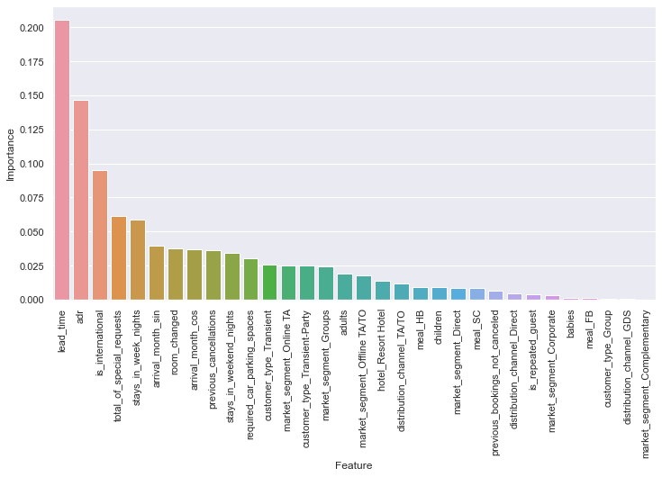

```python
df_feat_impor = pd.DataFrame({'Feature': rf_clf.feature_names_in_, 'Importance': rf_clf.feature_importances_})
df_feat_impor.sort_values('Importance', axis=0, ascending=False, inplace=True)
df_feat_impor
plt.figure(figsize=(12,6))
sns.barplot(data=df_feat_impor[df_feat_impor['Importance']>0], x='Feature', y='Importance')
plt.xticks(rotation=90)
plt.show()
```

### Conclusiones

Hemos entrenado un primer árbol de decisión extraido las reglas de decisión que lo forman, obtenido las variables más importantes para la clasificación y evaluado su comportamiento con distintas métricas. Lo hemos comparado con otras versiones de árboles realizando una búsqueda entre diferentes parámetros y hemos sacado la conclusión de que con el set de datos que tenemos, un árbol con pocas restricciones es el que nos proporciona mejor comportamiento.

Por otro lado, hemos evaluado la poda del árbol, con la que hemos conseguido una mejora sobre el árbol base, y con la que de hecho hemos obtenido los mejores resultado de entre todos los modelos probados sobre el árbol de decisión simple con un *accuracy* del 85.5%, que no es un resultado nada malo.

Por último, hemos evaluado dos métodos de *ensamble*, que combinan la creación de varios árboles para mejorar la capacidad predictiva:

- AdaBoost ha conseguido unos resultados ligeramente peores que los proporcinados por el modelo inicial con poda, por lo que no ha resultado ser especialmente interesante en este caso, además de ser sustancialmente más lento de entrenar.
- Con RandomForest hemos conseguido los mejores resultados en clasificación de todos, obteniendo una mejora notable respecto al árbol de decisión incial, e incluso al optimizado restringiendo su tamaño o con opciones de poda, y sin duda sería con la opción elegida para nuestro caso. Hay que decir que este resultado no es sorprendente, pues este algoritmo suele proporcionar resultados muy buenos para un gran abanico de problemas.

## **Ejercico 5**: Aplicar un modelo supervisado diferente al anterior.

### Modelo k nearest neighbors

Como alternativa de modelo supervisado a los árboles de decisión, probamos con el algoritmo *k nearest neighbors*. Este algoritmo, al basarse en distancia, es sensible a las diferentes escalas que presentan los datos en la entrada, por lo que es imporatante realizar una normalización previa de éstos para obtener los mejores resultados. El parámetro más importante que definirá la clasificación del algoritmo es el valor que asignemos a *k*, que es el número de muestras que tomaremos como referencia a la hora de clasificar. De esta forma, para clasificar una muestra, se toman los *k* vecinos más cercanos en el espacio multidimensional de variables de entrada y se asigna a la muestra la clase más común de entre esos *k* vecinos.

En un primer momento entrenamos el modelo eligiendo el valor de *k* de forma arbitraria a 3.

```python
from sklearn.neighbors import KNeighborsClassifier
from sklearn.pipeline import Pipeline
from sklearn.preprocessing import StandardScaler

knn_pipe = Pipeline([('scaler', StandardScaler()),
                     ('clf', KNeighborsClassifier(n_neighbors=3))])
knn_score = cross_validate(knn_pipe, X_train, y_train, scoring=score_types, return_train_score=True, cv=5, n_jobs=16)
```

### Evaluación del modelo

Evaluamos diferentes métricas de calidad de la clasificación, tanto en el conjunto de entrenamiento como en el de evaluación realizando cross-validation.

```python
show_mean_scores(knn_score)
```

|  | train | test |
| --- | --- | --- |
| accuracy | 0.911619 | 0.837997 |
| precision | 0.892225 | 0.792961 |
| recall | 0.869348 | 0.768740 |
| f1 | 0.880638 | 0.780655 |
| roc | 0.973308 | 0.889836 |

Mostramos la matriz de confusión que tenemos con este modelo.

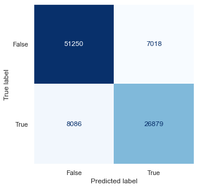

```python
y_pred = cross_val_predict(knn_pipe, X_train, y_train, cv=5, n_jobs=16)
plt.figure(figsize=(10,5))
ConfusionMatrixDisplay.from_predictions(y_train, y_pred, colorbar=False, cmap='Blues', ax=plt.gca())
plt.grid(False)
plt.show()
```

De la matriz de confusión podemos decir que de las 34965 muestras de la clase "True" (reservas no canceladas), 26879 se han correctamente clasificado como "True", lo que hace un 76.9%, valor que correponde con el *recall* que hemos calculado en el punto anterior. Por otro lado, de las 33897 muestras que se han clasificado como "True", sólo lo eran 26879, que son un 79.3% y corresponde con el valor de *precision* que hemos calculado.

Por último, comparamos el valor de exactitud logrado en los conjuntos de entrenamiento, validación y test.

```python
knn_pipe.fit(X_train, y_train)
y_pred_test = knn_pipe.predict(X_test)
print(f'Train accuracy score is : {np.mean(knn_score["train_accuracy"])*100:.2f}%')
print(f'Evaluation accuracy score by cross-validation is : {np.mean(knn_score["test_accuracy"])*100:.2f}%')
print(f'Final test accuracy score is : {accuracy_score(y_test, y_pred_test)*100:.2f}%')
```

```
Train accuracy score is : 91.16%
Evaluation accuracy score by cross-validation is : 83.80%
Final test accuracy score is : 83.96%
```

En los resultados anteriores puede verse como los conjuntos de evaluación y test tienen un comportamiento parecido, pero el de entrenamiento tiene una exactitud claramente superior, signo de que el el modelo sufre de *overfitting*. Para solucionarlo, en el apartado siguiente haremos un barrido con el parámetro *k*, que es el que nos pemitirá controlarlo en este algoritmo. Un valor más grande de *k* querrá decir que la clasificación de una muestra tendrá en cuenta un mayor número de muestras cercanas, por lo que las fronteras de decisión serán más suaves, y por lo tanto el modelo tenderá menos a apender el ruido de un conjunto de entrenamiento y capturará más la tendencia general de éstos.

### Optimización o *parameter hypertuning*

Vamos a realizar el proceso de *parameter hypertuning* para escoger el mejor set de parámetros del modelo para este conjunto de datos en concreto. El algoritmo *k nearest neighbors* es un algoritmo sencillo que básicamente viene definido por su parámetro *k*, por lo que haremos un barrido en éste para calcular cual es su valor óptimo.

```python
parameters_knn = {'clf__n_neighbors':[1,2,3,4,5,6,7,8,9,11,13,15,19,25]}

clf_knn_gs = GridSearchCV(knn_pipe, parameters_knn, scoring='accuracy', cv=5, n_jobs=16)
clf_knn_gs.fit(X_train, y_train)
```

```
GridSearchCV(cv=5,
             estimator=Pipeline(steps=[('scaler', StandardScaler()),
                                       ('clf',
                                        KNeighborsClassifier(n_neighbors=3))]),
             n_jobs=16,
             param_grid={'clf__n_neighbors': [1, 2, 3, 4, 5, 6, 7, 8, 9, 11, 13,
                                              15, 19, 25]},
             scoring='accuracy')
```

Guardamos el modelo que mejor resultado nos ha proporcionado en *accuracy*.

```python
best_knn = clf_knn_gs.best_estimator_
best_knn
```

```
Pipeline(steps=[('scaler', StandardScaler()),
                ('clf', KNeighborsClassifier(n_neighbors=8))])
```

Y visualizamos los resultados obtenidos con los distintos valores de *k*.

```python
results = pd.DataFrame(clf_knn_gs.cv_results_)[['param_clf__n_neighbors', 'mean_test_score', 'std_test_score']]
results
```

|  | param_clf__n_neighbors | mean_test_score | std_test_score |
| --- | --- | --- | --- |
| 0 | 1 | 0.834790 | 0.001635 |
| 1 | 2 | 0.835659 | 0.001627 |
| 2 | 3 | 0.837997 | 0.001448 |
| 3 | 4 | 0.840046 | 0.001220 |
| 4 | 5 | 0.840518 | 0.001464 |
| 5 | 6 | 0.841076 | 0.001126 |
| 6 | 7 | 0.840561 | 0.001262 |
| 7 | 8 | 0.841301 | 0.000962 |
| 8 | 9 | 0.841033 | 0.000409 |
| 9 | 11 | 0.840668 | 0.000488 |
| 10 | 13 | 0.840250 | 0.001508 |
| 11 | 15 | 0.839156 | 0.001299 |
| 12 | 19 | 0.838416 | 0.001865 |
| 13 | 25 | 0.835176 | 0.002242 |

Al entrenar y evaluar varios modelos con distintos conjuntos de datos de entrenamiento y evaluación, el método de *cross-validation* tiene la ventaja adicional de que podemos obtener, no sólamente una media de su métrica de calidad (en este caso *accuracy*), sino también la desviación típica de ésta, por lo que podemos saber cuánto de estable es ese resultado que hemos obtenido.

Mostramos el valor de *accuracy* promedio de forma gráfica.

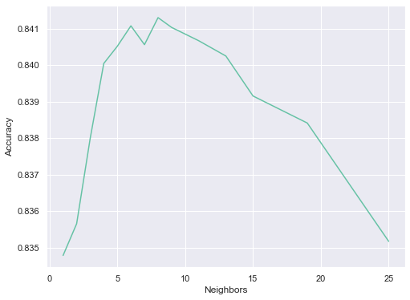

```python
plt.figure(figsize=(8,6))
sns.lineplot(data=results, x='param_clf__n_neighbors', y='mean_test_score')
plt.xlabel('Neighbors')
plt.ylabel('Accuracy')
plt.show()
```

Podemos comprobar cómo el valor máximo de *accuracy* lo obtenemos cuando fijamos *k* a un valor de 8, y por lo tanto este sería el valor elegido para este parámetro. Se puede observar cómo la exactitud disminuye con una *k* menor, caso en el que sufriremos de *overfitting* y el modelo aprende demasiado bien las peculiaridedes del conjunto de entrenamiento pero generaliza mal, y también con *k* mayor, donde sufriremos de *underfitting* por tener un modelo demasiado sencillo. En este caso particular, sin embargo, aunque hay un valor óptimo, no vemos una gran diferencia en el comportamiento final con todo el barrido que hemos realizado, pues las diferencias son de ~0.5% en *accuracy*, por lo que la optimización en rendimiento que podemos lograr con este parámetro es muy limitada.

Evaluamos diferentes métricas de calidad de la clasificación, tanto en el conjunto de entrenamiento como en el de evaluación realizando cross-validation, y podemos comprobar cómo con este valor óptimo de *k* la diferencia entre los conjuntos de entrenamiento y test es menor, ya que hemos reducido el *overfitting* aumentando el valor de *k*.

```python
knn_best_score = cross_validate(clf_knn_gs.best_estimator_, X_train, y_train, scoring=score_types, return_train_score=True, cv=5, n_jobs=16)
```

```python
show_mean_scores(knn_best_score)
```

|  | train | test |
| --- | --- | --- |
| accuracy | 0.872285 | 0.841301 |
| precision | 0.885565 | 0.839158 |
| recall | 0.757329 | 0.713628 |
| f1 | 0.816436 | 0.771309 |
| roc | 0.950967 | 0.912952 |

### Se comparan y comentan los resultados de manera exhaustiva con el anterior método de construcción

Compararemos varios modelos de los que hemos entrenado para comparar sus resultados:

- Modelo inicial de árbol de decisión
- Árbol de decisión sin restricciones
- Mejor opción de árbol con poda
- Random Forest
- Mejor opción de algoritmo *k nearest neighbors*.

```python
classifiers = [dt_classifier, decission_tree, best_pruned_dt, rf_clf, best_knn]
classifiers_name = ['initial_dt', 'complex_dt', 'pruned_dt', 'random_forest', 'knn']
scores = {}

for clf, clf_name in zip(classifiers, classifiers_name):
    clf_scores = cross_validate(clf, X_train, y_train, scoring=score_types, cv=10, n_jobs=16)
    test_accuracy = clf_scores['test_accuracy']
    print(f'{clf_name} model fitted...')
    for metric in score_types:
        scores[(clf_name, metric)] = clf_scores['test_'+metric]
```

```
initial_dt model fitted...
complex_dt model fitted...
pruned_dt model fitted...
random_forest model fitted...
knn model fitted...
```

```python
df_scores = pd.DataFrame(scores)
df_scores
```

|  | initial_dt accuracy | initial_dt precision | initial_dt recall | initial_dt f1 | initial_dt roc_auc | complex_dt accuracy | complex_dt precision | complex_dt recall | complex_dt f1 | complex_dt roc_auc | ... | random_forest accuracy | random_forest precision | random_forest recall | random_forest f1 | random_forest roc_auc | knn accuracy | knn precision | knn recall | knn f1 | knn roc_auc |
| --- | --- | --- | --- | --- | --- | --- | --- | --- | --- | --- | --- | --- | --- | --- | --- | --- | --- | --- | --- | --- | --- |
| 0 | 0.821965 | 0.787841 | 0.718902 | 0.751794 | 0.897766 | 0.842557 | 0.782041 | 0.804404 | 0.793065 | 0.837664 | ... | 0.872801 | 0.848357 | 0.804690 | 0.825947 | 0.945207 | 0.841484 | 0.833719 | 0.721190 | 0.773382 | 0.913666 |
| 1 | 0.827649 | 0.790769 | 0.734916 | 0.761820 | 0.902041 | 0.848241 | 0.796075 | 0.800400 | 0.798232 | 0.841284 | ... | 0.880845 | 0.866626 | 0.806405 | 0.835432 | 0.949968 | 0.847383 | 0.848923 | 0.721476 | 0.780028 | 0.918441 |
| 2 | 0.831081 | 0.800877 | 0.731484 | 0.764609 | 0.905871 | 0.845667 | 0.798780 | 0.786674 | 0.792681 | 0.835851 | ... | 0.878700 | 0.863106 | 0.804118 | 0.832568 | 0.949928 | 0.848992 | 0.851802 | 0.723191 | 0.782246 | 0.917413 |
| 3 | 0.823876 | 0.791143 | 0.720538 | 0.754192 | 0.897273 | 0.841789 | 0.785210 | 0.795767 | 0.790453 | 0.834092 | ... | 0.875040 | 0.858505 | 0.798341 | 0.827331 | 0.942738 | 0.836426 | 0.835318 | 0.702231 | 0.763015 | 0.907628 |
| 4 | 0.831921 | 0.793607 | 0.745709 | 0.768913 | 0.905026 | 0.849512 | 0.797217 | 0.802918 | 0.800057 | 0.842790 | ... | 0.883085 | 0.863444 | 0.817506 | 0.839847 | 0.950961 | 0.846830 | 0.841931 | 0.728261 | 0.780982 | 0.920669 |
| 5 | 0.823876 | 0.793912 | 0.716247 | 0.753083 | 0.901886 | 0.849297 | 0.798458 | 0.800057 | 0.799257 | 0.841704 | ... | 0.876756 | 0.854853 | 0.808638 | 0.831104 | 0.947897 | 0.839215 | 0.834955 | 0.711957 | 0.768566 | 0.913073 |
| 6 | 0.826236 | 0.784587 | 0.739703 | 0.761484 | 0.901435 | 0.843184 | 0.782186 | 0.806350 | 0.794085 | 0.837145 | ... | 0.878473 | 0.857922 | 0.810069 | 0.833309 | 0.949529 | 0.844363 | 0.836903 | 0.726545 | 0.777829 | 0.914577 |
| 7 | 0.825593 | 0.797771 | 0.716533 | 0.754973 | 0.899604 | 0.844256 | 0.785954 | 0.803490 | 0.794625 | 0.837458 | ... | 0.877293 | 0.858537 | 0.805492 | 0.831169 | 0.947056 | 0.841682 | 0.839382 | 0.714531 | 0.771941 | 0.914604 |
| 8 | 0.831385 | 0.796427 | 0.739491 | 0.766904 | 0.906724 | 0.850906 | 0.797179 | 0.808121 | 0.802613 | 0.846150 | ... | 0.880725 | 0.861473 | 0.812697 | 0.836374 | 0.951726 | 0.843827 | 0.842795 | 0.717472 | 0.775100 | 0.913236 |
| 9 | 0.826022 | 0.782635 | 0.742351 | 0.761961 | 0.899969 | 0.842325 | 0.787518 | 0.793823 | 0.790658 | 0.834737 | ... | 0.873431 | 0.855914 | 0.796683 | 0.825237 | 0.945534 | 0.844149 | 0.843414 | 0.717758 | 0.775529 | 0.913049 |

10 rows × 25 columns

```python
df_scores = df_scores.T.melt(value_name='score', var_name='cv', ignore_index=False).reset_index().rename(mapper={'level_0': 'model', 'level_1': 'metric'}, axis=1)
df_scores.head(10)
```

|  | model | metric | cv | score |
| --- | --- | --- | --- | --- |
| 0 | initial_dt | accuracy | 0 | 0.821965 |
| 1 | initial_dt | precision | 0 | 0.787841 |
| 2 | initial_dt | recall | 0 | 0.718902 |
| 3 | initial_dt | f1 | 0 | 0.751794 |
| 4 | initial_dt | roc_auc | 0 | 0.897766 |
| 5 | complex_dt | accuracy | 0 | 0.842557 |
| 6 | complex_dt | precision | 0 | 0.782041 |
| 7 | complex_dt | recall | 0 | 0.804404 |
| 8 | complex_dt | f1 | 0 | 0.793065 |
| 9 | complex_dt | roc_auc | 0 | 0.837664 |

Representamos de forma gráfica los valores obtenidos de *accuracy* en los 10 *folds* de cross-validation para cada uno de los modelos evaluados.

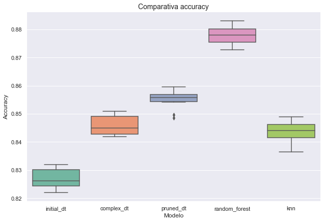

```python
def compare_metric(df, metric):
    sns.catplot(data=df[df['metric']==metric], x='model', y='score', kind='box', height=6, aspect=1.5)
    plt.xlabel('Modelo')
    plt.ylabel(metric.title())
    plt.title('Comparativa '+metric, fontsize=14)
    plt.show()

compare_metric(df_scores, 'accuracy')
```

Como se puede observar, *random forest* es con amplia diferencia el modelo que nos ofrece una mayor *accuracy*, a pesar de que es un modelo en el que no hemos realizado un proceso de ajuste en sus parámetros, tras lo cual es de esperar que obtuviesemos algo más de mejora. De entre los modelos de árbol de decisión sin *ensamble*, el mejor de todos es el realizado con el podado optimizado, como ya hemos visto. El algoritmo *k nearest neighbors* tiene un rendimiento similar al árbol de decisión sin restricciones y sin podado, si bien tiene la desventaja de tener un tiempo de cálculo mucho mayor que cualquiera de las opciones basados en árboles de decisión.

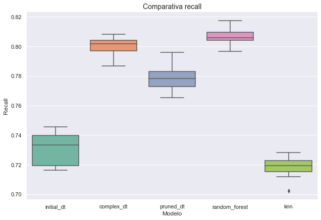

```python
compare_metric(df_scores, 'recall')
```

En la métrica *recall*, *random forest* vuelve a ser el algoritmo ganador, y *k nearest neigbors* junto con el árbol limitado realizado en primer lugar obtienen los peores datos.

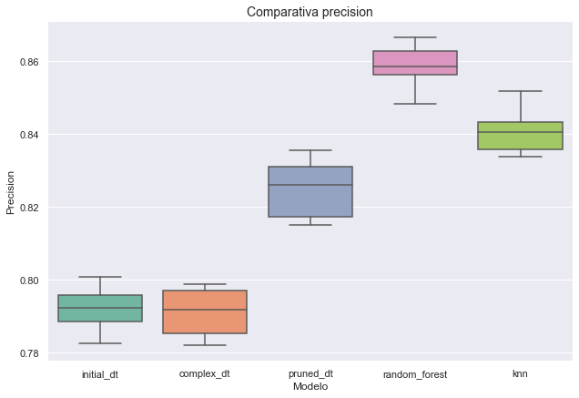

```python
compare_metric(df_scores, 'precision')
```

En la métrica *precision*, *random forest* vuelve a ser el algoritmo ganador, pero *k nearest neigbors* obtiene la segunda posición. Pese a que el árbol de decisión sin restringir obtiene muy buen valor en *recall*, lo hace muy mal en *precision*.

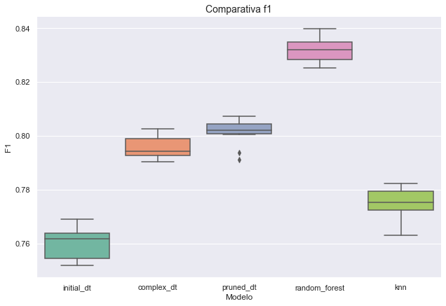

```python
compare_metric(df_scores, 'f1')
```

La métrica *f1-score* viene derivada de *precision* y *recall* y los resultados que vemos son muy parecedos a los que teníamos con *accuracy*, con *random forest* como claro ganador y el árbol de decisión inicial y *knn* como los que peor se comportan.

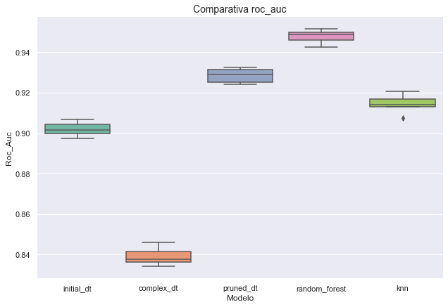

```python
compare_metric(df_scores, 'roc_auc')
```

Si tenemos en cuenta la métrica de área bajo la curva ROC, llama la atención el modelo de árbol complejo, que obtiene con diferencia el peor de los resultados, a pesar de no hacerlo tan mal en *accuracy*. En esta métrica nuevamente es *random forest* el que mejor se comporta, con el árbol con podado optimizado en segundo lugar, obteniendo 0.95 y 0.93 respectivamente, unos números nada despreciables.

Realizada la comparativa de los modelos que hemos probado con distintas métricas, se pueden extraer algunas conclusiones:

- **No hay siempre un modelo que sea el claro ganador** y dependerá de la métrica de calidad que nos interese para decantarnos por uno u otro. Dicho esto, deberíamos elegir cuidadosamente la métrica utilizada para no elegir un modelo que en realidad no nos proporciona la mejor calidad. El árbol sin restricciones, por ejemplo, es uno de los mejores en la medida *recall*, y sin embargo es de los peores en *precision* y claramente el peor en el área bajo la curva ROC.
- Tenemos que tener en cuenta que las optimizaciones que hemos realizado en modelos como el árbol con podado y el knn, las hemos realizado teniendo en cuenta la métrica de *accuracy*, por lo que deberíamos realizarla con la métrica elegida para encontrar con el mejor set de parámetros según esa métrica en concreto.
- *Accuracy* no es muchas veces la mejor métrica para medir la calidad de un modelo. En primer lugar, nos puede llevar a engaño si las clases objetivo no están balanceadas (como es nuestro caso), y además da la misma importancia a los distintos tipos de errores que podemos cometer en la clasificación (falsos positivos y falsos negativos). Como siempre podremos tener un compromiso entre *precision* y *recall* moviendo el umbral de decisión (algo que no hemos realizado en esta práctica), el área bajo la curva ROC suele ser una buena métrica a elegir.
- En nuestro caso particular en cualquiera de las métricas tenemos como ganador el *random forest*, por lo que en principio y salvo que encontrásemos algo que nos lo impidiese, elegiríamos sin duda este modelo. Además, este modelo no lo hemos optimizado, por lo que seguramente podríamos obtener unos resultados algo mejores tras este paso.

### Evaluación final del modelo

Tras haber elegido el modelo de *random forest* mediante el proceso de validación con *cross-validation*, ahora sí es el momento te utilizar el conjunto de test que habíamos reservado al comienzo para comprobar cómo se comportaría el modelo con datos nunca vistos, datos que no hemos utilizado ni para el entrenamiento ni para la toma de decisión sobre el modelo a utilizar.

```python
from sklearn.metrics import accuracy_score, precision_score, recall_score, f1_score, roc_auc_score
rf_clf.fit(X_train, y_train)
y_predict = rf_clf.predict(X_test)
print(f'Final accuracy is: {accuracy_score(y_test, y_predict)*100:.2f}%')
print(f'Final precision is: {precision_score(y_test, y_predict)*100:.2f}%')
print(f'Final recall is: {recall_score(y_test, y_predict)*100:.2f}%')
print(f'Final f1-score is: {f1_score(y_test, y_predict)*100:.2f}%')
print(f'Final ROC AUC score is: {roc_auc_score(y_test, y_predict):.4f}')
```

```
Final accuracy is: 87.78%
Final precision is: 86.08%
Final recall is: 80.65%
Final f1-score is: 83.28%
Final ROC AUC score is: 0.8637
```

Los resultados, como puede verse, son muy prometedores, con una exactitud de casi el 88%.

## **Ejercico 6**: Identificar limitaciones del dataset seleccionado y analizar los riesgos para el caso de uso.

### Limitaciones de los datos para obtener conclusiones con los modelos supervisados y no supervisados

En la primera parte de la práctica, PRA1, fue elegido un dataset para un proyecto de minería de datos. El dataset elegido era el de datos históricos de reservas de hoteles, que incuían una *etiqueta* o clase binaria que determinaba si dicha reserva acababa siendo cancelada o no. Esta información, tanto en forma de clase objetivo binaria (una reserva a a ser o no cancelada) como en su forma de probabilidad (probabilidad de que dicha reserva vaya a ser cancelada) puede llevarnos a tomar decisiones que optimize costes y beneficios de hoteles, agencias de viajes y webs de reservas de hoteles.

Dado el dataset elegido y el problema que se planteaba inicialmente, el objetivo de la segunda práctica era el de aplicar algoritmos de aprendizaje supervisado, que tomasen como objetivo la predicción de la clase objetivo: la cancelación o no de una reserva de hotel. Esto es lo que hemos realizado en los ejercicios 4 y 5 de esta PRA2, y en los que hemos evaluado el comportamiento en clasificación de distintos tipos de árboles de decisión, métodos de *ensamble* basados en éstos y k nearest neighbors. Hemos evaluado distintas métricas para cada uno de ellos y su rendimiento en los distintos conjuntos de datos. También hemos lidiado con los problemas de *overfitting* y *overfitting* que se nos han presentado en los modelos ajustando los parámetros que nos ofrece cada uno de los modelos para regularizarlos (controlar su complejidad). El resultado final ha sido basante prometedor, ya que el mejor de nuestro modelos nos ha reportado casi un 88% de *accuracy*, con valores prometedores también en el resto de métricas de calidad. Por supuesto, con más trabajo estos números todavía podrían mejorarse más con un *feature engineering* o búsqueda de variables que puedan tener mayor capacidad predictiva, con la evaluación de nuevos modelos (SVM, redes neuronales, etc...), ajuste más fino de los parámetros de cada modelo, etc, pero desde luego tenemos un punto de partida muy prometedor.

El resultado no ha sido igual de prometedor, sin embargo, con la aplicación de modelos no supervisados. En este caso no tenemos unos clusters claros definidos en el espacio n-dimensional, y por ello los algoritmos de DBSCAN y OPTICS fallan estrepitosamente: los resultados que proporcionan ambos son francamente malos, creando un único cluster con prácticamente la totalidad de muestras (DBSCAN con *eps* alto) o clasificando la mayoría de muestras como *outliers* (DBSCAN con *eps* bajo y OPTICS), eso a pesar de haber realizado una más o menos exahustiva búsqueda de los mejores valores para los parámetros principales que definen a ambos algoritmos. Es por ello que debemos descartar el uso de estos algoritmos de *clustering* para este set de datos. Kmeans sí que se puede aplicar y nos crea clusters de una forma razonable, pero al no existir estos clusters de forma más o menos definida, los valores de las métricas que evaluamos, como el coeficiente silhouette, son bastante pobres.

### Riesgos de uso del modelo

Como hemos comentado en el apartado anterior, el dataset fue elegido con el objetivo de aplicar modelos de aprendizaje supervisado tomando como objetivo la predicción de si una reserva iba a ser o no cancelada y hemos conseguido con estos modelos unos resultados prometedores, por lo que nos centraremos en los riesgos de uso en este caso de aplicación, que conincide además con la planteada inicialmente. Algunos de los risgos que podemos identificar son:

- Tenemos actualmente datos de reservas de dos hoteles de Portugal. Aplicar el modelo de predicción a reservas realizadas en otros hoteles, todavía más en otros países, puede ser muy aventurado y es probable que el modelo no funcionase de la forma esperada. Dicho de otra forma, es probable que las métricas de calidad bajasen de forma clara. Esto es debido a que el patrón de reservas de hoteles puede ser muy distinto para unos hoteles u otros, ya que ni el tipo de cliente es el mismo, ni el tipo de estancia que va a realizar en el hotel es la misma, etc. De hecho, este comportamiento distinto ya lo hemos visto en los dos hoteles de los que disponemos datos (hotel de ciudad y resort), por lo que es de esperar que a escala más global pase lo mismo. Si quisiésemos realizar un modelo más universal, para empezar necesitaríamos datos de todos los hoteles sobre los que queramos realizar predicciones o al menos una muestra representativa de éstos, y podríamos tener una variable en los datos que nos clasificase el tipo de hotel. Esta agrupación de hoteles en diferentes clases atendiendo a diferentes características (país, zona ciudad/rural/playa/monte, etc) podría realizarse, por ejemplo, con un algoritmo de *clustering* como los evaluados en esta práctica, y esta variable introducirse en nuestro modelo de clasificación como una más.
- Tenemos datos de ciertos años, pero los hábitos de consumo, incluídos los del turismo, cambian a lo largo del tiempo, incluso sin tener en cuenta eventos excepcionales como una pandemia mundial. Esto quiere decir que deberemos re-entrenar nuestro modelo de forma periódica para que el comportamiento de éste no se vea deteriorado. Si no lo hacemos, inevitablemente las métricas que miden la calidad de nuestro modelo irán descendiendo con los nuevos datos que entran de nuevas reservas, cuya cancelación ya no seremos capaces de predicir con la misma fiabilidad. Tendremos por lo tanto que ir almacenando todos los nuevos datos de los que dispongamos y, bien en tiempo real o bien con una periodicidad razonable, entrenar de nuevo nuestro modelo. Para esto podemos hacer un entrenamiento nuevo completo o bien sólo un entrenamiento incremental con los nuevos datos. También podemos aplicar un peso mayor a los nuevos datos (haciendo sobremuestreo, por ejemplo) para que la adaptación a estos cambios de los consumidores sean más rápidos, así como ir descartando los datos que tengamos más antiguos y que quizás hayan perdido ya relevancia en el contexto actual y no nos hagan más que introducir ruido en nuestro modelo.

## **Bibliografía**

- https://scikit-learn.org/stable/index.html
- https://pypi.org/project/pyclustering/
- https://machinelearningknowledge.ai/tutorial-for-dbscan-clustering-in-python-sklearn/
- https://towardsdatascience.com/dbscan-algorithm-complete-guide-and-application-with-python-scikit-learn-d690cbae4c5d
- https://medium.com/@haataa/how-to-measure-clustering-performances-when-there-are-no-ground-truth-db027e9a871c
- https://medium.com/@cmukesh8688/silhouette-analysis-in-k-means-clustering-cefa9a7ad111
- https://scikit-learn.org/stable/auto_examples/cluster/plot_kmeans_silhouette_analysis.html
- https://www.analyticsvidhya.com/blog/2020/10/quick-guide-to-evaluation-metrics-for-supervised-and-unsupervised-machine-learning/
- https://towardsdatascience.com/metrics-to-evaluate-your-machine-learning-algorithm-f10ba6e38234
- https://www.cienciadedatos.net/documentos/30_cross-validation_oneleaveout_bootstrap